# Notes de cours

Antoine Gagné

5 février 2016

Ce document regroupe l’ensemble de mes notes pour le cours **Modèles et langages de bases de données**.

# 1 Introduction

Ce chapitre est une introduction aux bases de données et aux système de gestion de bases de données. Il expliquera leur raison d’exister, les fonctions typiques, les composants majeurs, etc.

## 1.1 L’ancêtre des bases de données

Le prédécesseur des bases de données est l’approche par fichiers. Cette approche utilisait un système décentralisé où chaque système avait ses propres données.

### 1.1.1 Problèmes

L’approche par fichiers comprend cinq problèmes majeurs.

#### 1.1.1.1 Séparation et isolation des données

Dans une approche par fichiers, les données sont séparées et isolées. Cela fait en sorte qu’il est plus difficile d’accéder aux données. Lorsqu’on veut accéder à des données, on doit synchroniser notre traitement des fichiers pour s’assurer que les bonnes données sont extraites.

#### 1.1.1.2 Duplication des données

Un autre problème de cette approche est la duplication des données. Chaque département a sa propre version des données. Cela fait en sorte que les départements vont avoir des données identiques entre eux dans certains cas. C’est donc du gaspillage de temps et d’argent, car les données être entrées plusieurs fois par des personnes différentes. De plus, ça veut également dire qu’il y a plus d’espace de stockage qui est pris. Finalement, il y a plus de risques d’avoir des informations incorrectes, car il peut y arriver que la synchronisation entre les différents fichiers des départements ne s’est pas bien faite.

#### 1.1.1.3 Dépendences des données

Les programmes dépendent d’un format de fichier particulier. Si le format change, toutes les applications connectées à ce fichier doivent changer aussi. Le format des données est donc assez rigide, car il n’y a pas d’abstraction quant à la disposition de celles-ci. De plus, changer une adresse de données va nécessiter la création d’un programme pour pouvoir changer tous les champs de manière à ce qu’ils soient conformes à la nouvelle structure.

#### 1.1.1.4 Format de fichiers

Comme la structure des fichiers est dépendant du langage de programmation, il est plus difficile d’utiliser différents langages pour les différentes applications. En effet, un fichier généré dans un langage va être différent du même fichier généré à partir d’un autre langage.

#### 1.1.1.5 Requêtes fixes et prolifération de programmes

Les besoins de nouvelles requêtes peuvent changer à tous moments. Étant donné que les requêtes sont écrites par les développeurs d’application, il était très difficile d’ajouter des nouvelles requêtes rapidement. Il n’y avait aucun moyen de créer des requêtes non planifiées pour aller voir les types de données disponibles. Le fait que ce soit les développeurs d’application qui devaient écrire toutes les requêtes faisait en sorte que leur charge de travail était énorme et, donc, dans certain cas, ils étaient obligés de couper dans certaines fonctionnalités. Par exemple, les fonctionnalités suivantes étaient souvent omises:

- Aucune mesure de sécurité ou de vérification de l’intégrité des données
- La récupération des données dans le cas d’un disfonctionnement logiciel ou matériel était limité ou inexistant
- Accès aux fichier était restreint à un utilisateur à la fois

#### 1.1.1.6 Résumé

Tous les facteurs limitants de l’approche par fichiers peuvent être attribués à deux facteurs:

- La définition des données est incrustée dans les applications au lieu d’être enregistré séparemment et indépendemment
- Il n’y a aucun contrôle sur les accès et manipulations des données hormis celui imposé par les programmes

## 1.2 L’approche par base de données

L’approche par fichiers ne répondant pas aux besoins des entreprises, une nouvelle solution fut inventée: l’approche par base de données.

### 1.2.1 Les bases de données

#### 1.2.1.1 Définition

Une **base de données** est une collection de données liées logiquement et sa description, conçu dans le but de répondre aux besoins d’information d’une organisation.

#### 1.2.1.2 Avantages

Les bases de données ont plusieurs avantages par rapport à l’approche par fichiers. Par exemple:

- Une base de données a le minimum de duplication possible.
- Au lieu d’être liée à un seul département, elle est partagée à toute l’organisation complète.
- Elle peut être accédée par plusieurs utilisateurs en même temps.
- En plus de contenir les données, elle contient aussi une description de ces données.
- La définition des données est cachée aux utilisateurs qui ne voient que leurs définitions externes ce qui permet de protéger les programmes des modifications à la base de données.

### 1.2.2 Les systèmes de gestion de bases de données (DBMS ou SGBD)

#### 1.2.2.1 Définition

Un **système de gestion de base de données** est un logiciel qui permet aux utilisateurs de définir, créer, maintenir et contrôler l’accès à la base de données.

#### 1.2.2.2 Fonctionnalités fournies

Les systèmes de gestion de bases de données donnent accès à des fonctionnalités. Par exemple:

- Permet aux utilisateurs de définir la base de données avec un **langage de définition de données (DDL)**. Ce langage permet de spécifier les types, les structures et les contraintes à appliquer sur les données qui vont être entreposées dans la base de données.
- Permet aux utilisateurs de d’insérer, de mettre à jour, d’effacer et d’aller chercher des données dans la base de données avec un **langage de manipulation de données (DML)**. Le langage de manipulation de données permet de faire ces opérations avec un **langage de requête** comme le **langage structuré de requête (SQL)**.
- Permet un accès contrôlé à la base de données. Par exemple:
  - Système de sécurité qui empêche les accès non autorisés à la base de données
  - Système d’intégrité qui maintient la consistence des données
  - Système de contrôle d’accès multiple qui permet l’accès partagé à la base de données
  - Système de contrôle de récupération qui permet de remettre la base de données à un état antérieur après un problème matériel ou logiciel
  - Catalogue usager qui contient des descriptions des données dans la base de données

#### 1.2.2.3 Avantages

Il y a plusieurs avantages aux systèmes de gestion de bases de données. Parmi ces avantages, on dénombre le contrôle de la redondance des données, la cohérence des données, plus d’informations avec le même nombre de données, le partage des données, une meilleure intégrité des données, une sécurité accrue, l’application des standards, des économies de taille, la balance de besoins contradictoires, l’amélioration de l’accessibilité et de la réactivité des données, une productivité accrue, maintenance améliorée grâce à l’indépendence des données, amélioration de l’accès simultané et de meilleurs services de restauration des données.

##### 1.2.2.3.1 Contrôle de la redondance des données

L’approche par bases de données essaie d’éliminer les redondances en intégrant les fichiers de sorte que des copies des mêmes données ne sont pas enregistrées. Toutefois, l’approche par bases de données n’élimine pas toutes les redondances, elle ne fait que contrôler la quantité de redondance. Dans certains cas, il est nécessaire de dupliquer des données clés pour modéliser des relations. Dans d’autres cas, il est désirable de dupliquer quelques données pour améliorer les performances.

##### 1.2.2.3.2 Cohérence des données

En éliminant ou en controllant les redondances, on réduit le risques d’incohérences. S’il n’y a qu’une copie d’une données dans la base de données, n’importe quelle mise à jour de sa valeur ne va devoir être fait qu’une fois. S’il y a plusieurs copies et que le système est au courant, il peut s’assurer que toutes les copies sont consistentes.

##### 1.2.2.3.3 Plus d’informations avec le même nombre de données

Comme toutes les informations sont accessibles par tous les départements d’une organisation, il est possible d’avoir plus d’information avec les mêmes données.

##### 1.2.2.3.4 Partage des données

Comme la base de données est commune à toute l’organisation, elle peut être accéder par tout le monde.

##### 1.2.2.3.5 Meilleure intégrité des données

L’intégrité d’une base de données réfère à la validité et à la cohérence des données enregistrées. L’intégrité est exprimé en termes de contraintes que la base de données ne peut violer.

##### 1.2.2.3.6 Sécurité accrue

La sécurité des bases de données est la protection de la base de données contre les utilisateurs non autorisés. L’intégraton permet à l’administrateur de la base de données de définir la sécurité de la base de données. Cette sécurité peut prendre la forme d’identifiants et de mots de passe.

##### 1.2.2.3.7 Application des standards

L’intégraton permet à l’administrateur de la base de données d’appliquer les standards nécessaires. Ceux-ci peuvent prendre la forme de format de données, format de la documentation, les procédures de mise à jour et règles d’accès.

##### 1.2.2.3.8 Économies de taille

Combiner toutes les données d’une organisations dans une base de données et créer un ensemble d’application qui marche avec cette seule source de données peut permettre d’économiser beaucoup d’argent. En effet, au lieu que chaque département ait leur propre budget pour la maintenant et le développement de leur système basé sur une approche fichier, les efforts peuvent être combinés pour être concentré vers la base de données uniques pouvant ainsi sauver de l’argent.

##### 1.2.2.3.9 Balance de besoins contradictoires

Chaque utilisateur ou département a des besoins qui peuvent être en conflit avec ceux des autres utilisateurs. Comme la base de données est sous le contrôle de l’administrateur de bases de données, celui-ci peut prendre des décisions à propos de la conception et de l’utilisation de la base de données qui vont tirer le maximum des ressources disponibles de l’organisation.

##### 1.2.2.3.10 Amélioration de l’accessibilité et de la réactivité des données

En raison de l’intégration, les données qui sont partagées à travers les frontières des différents départements sont directement accessibles aux utilisateurs. Cela donne un système qui a potentiellement beaucoup plus de fonctionnalités.

##### 1.2.2.3.11 Productivité accrue

Un système de gestion de gestion de bases de données fourni par défaut la plupart des fonctionnalités d’une approche par fichiers. Ainsi, le programmeur n’a pas à se concentrer sur les aspects de base de la base de données et peut se concentrer sur les aspects plus spécifiques à sa propre application.

##### 1.2.2.3.12 Maintenance améliorée grâce à l’indépendence des données

Un système de gestion de bases de données sépare la description des données des applications, rendant ainsi les applications immunisées contre les changements de descriptions des données.

##### 1.2.2.3.13 Amélioration de l’accès simultané

La plupart des systèmes de gestion de bases de données contrôlent les accès simultanés à la base de données rendant ainsi les problèmes d’accès simultanés impossible.

##### 1.2.2.3.14 Meilleurs services de restauration et de sauvegarde des données

Les systèmes de gestion de bases de données ont des mesures pour minimiser les dégats en cas de défaillance.

#### 1.2.2.4 Désavantages

Il y a aussi quelques désavantages aux systèmes de gestion de bases de données tels que une plus grande complexité, une plus grande taille, le coût des systèmes de gestion de bases de données, les coûts additionnels de matériel, le coût de conversion, la performance et un plus gros impact en cas de défaillance.

##### 1.2.2.4.1 Complexité

La plupart des fonctionnalités dont nous nous attendons d’un système de gestion de bases de données font en sorte que c’est un logiciel très complexe. Une incompréhension du système peut amener des mauvaises décisions de conception qui peuvent avoir des conséquences sérieuses pour l’organisation.

##### 1.2.2.4.2 Taille

La complexité et toutes les fonctionnalités des systèmes de gestion de bases de données font en sorte que c’est un logiciel extrêmement lourd qui demande beaucoup d’espace disque et qui demande beaucoup de mémoire pour l’exécuter.

##### 1.2.2.4.3 Coût des systèmes de gestion de bases de données

Le coût des systèmes de gestion de bases de données varie en fonction des fonctionnalités et de l’environnement fournis. Également, il y a des frais annuels de maintenance qui s’imposent.

##### 1.2.2.4.4 Coûts additionnels de matériel

Les besoins en espace de disque pour la base de données et le système de gestion de bases de données peut demander à acheter du nouvel espace disque. De plus, pour atteindre les performances requises, il peut être nécessaire d’acheter une machine dédiée pour exécuter la base de données.

##### 1.2.2.4.5 Coût de conversion

Dans certains cas, le coût de conversion des applications existants pour qu’elles roulent sur le nouveau système peut être très grand.

##### 1.2.2.4.6 Performance

Une approche par fichiers permet de créer des applications et des formats de fichier qui ont un but spécifique. Cela fait en sorte que leur performance est souvent très bonne. Par contre, dans le cas d’un système de gestion de bases de données, on essaie d’être plus général dans le but de desservir plus d’applications. Cette généralité entraîne souvent un coût au niveau de la performance.

##### 1.2.2.4.7 Plus gros impact en cas de défaillance.

La centralisation des données augmente la vulnérabilité du système. Comme tout le monde dépend de la base de données, sa défaillance peut amener plusieurs opérations à s’arrêter.

#### 1.2.2.5 Mécanisme de vision

En plus d’offrir toutes les fonctionnalités précédentes, les système de gestion de base de données offrent un **mécanisme de vue** qui permet aux utilisateurs d’avoir leur propre vue de la base de données. Par exemple, une vue pourrait permettre de ne voir que certaines entités de la base de données

##### 1.2.2.5.1 Bénéfices

Les vues offrent plusieurs bénéfices tels que:

- Un niveau de sécurité supplémentaire, car on peut exclure des données que certains utilisateurs ne devraient pas voir
- Un mécanisme pour paramétrer l’apparence de la base de données
- Permet de présenter une vision immutable de la structure de la base de données même si la base de données en dessous est changée, car la vue va seulement présentée les données qui intéressent l’utilisateur. Donc, même si les autres champs changent, tant que les champs qui intéressent l’utilisateur n’ont pas changé, la vue de l’utilisateur ne sera pas affectée.

#### 1.2.2.6 Composants d’un système de gestion de bases de données

Un système de gestion de bases de données est composées de plusieurs choses.

##### 1.2.2.6.1 Matériel

Un système de gestion de bases de données a besoin de matériel pour fonctionner. Ce matériel peut aller d’un simple ordinateur personnel à un réseau d’ordinateurs. Quelques systèmes de gestion de bases de données nécessite un système d’exploitation particulier ou du matériel spécifique alors que d’autres, non. Les système de gestion de bases de données ont besoin d’un minimum de mémoire et d’espace disque pour fonctionner, mais ce minimum ne garantit pas une performance adéquate. Un exemple d’**architecture client-serveur** se retrouve à la figure suivante. Dans cette figure, on remarque le serveur central qui sert de **backend** au système de gestion de bases de données et les différents ordinateurs qui servent de **frontend** au système de gestion de bases de données.

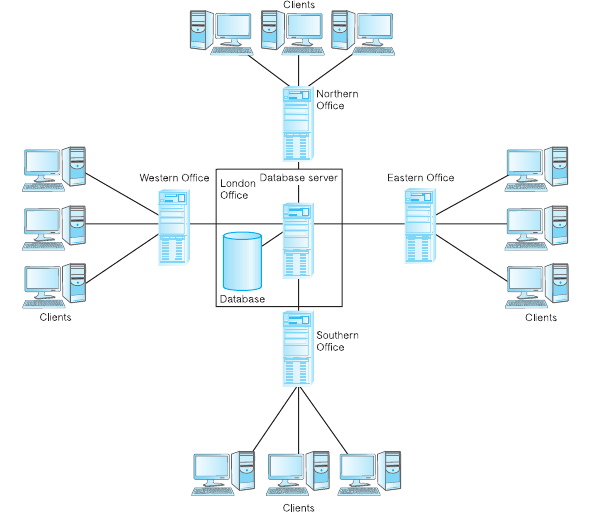

Exemple d’architecture client-serveur

##### 1.2.2.6.2 Logiciel

La composante logiciel comprend le logiciel de système de gestion de bases de données lui-même, les programmes d’application, le système d’exploitation et le logiciel de réseau si le système de gestion de bases de données est utilisé par un réseau.

##### 1.2.2.6.3 Données

Les données sont la partie la plus importante d’un système de gestion de bases de données. Elles servent de pont entre les humains et les machines. La base de données contient les données opérationnelles et les metadatas. La structure de la base de données est appelée **schéma**. Les schémas contiennent des **tables**. Les champs dans ces tables sont appelés des **attributs**.

##### 1.2.2.6.4 Procédures

Les procédures sont les instructions et les règles qui régissent la forme et l’utilisation de la base de données. Ces procédures sont destinées aux utilisateurs du système et au personnel qui est responsable de la base de données.

##### 1.2.2.6.5 Humains

Les personnes impliquées avec le système.

#### 1.2.2.7 Conception de bases de données

La structure d’une base de données est déterminée lors du **design de la base de données**.

#### 1.2.2.8 Rôles dans un environnement de bases de données

Il y a quatre types de personnes dans un environnement de bases de données. Il y a les administrateurs des données et de la base de données, les concepteurs de bases de données, les développeurs d’application et les utilisateurs.

##### 1.2.2.8.1 Administrateurs des données et de la base de données

Les administrateurs des données et de la base de données sont des rôles qui sont chargés du contrôle et de la gestion du système de gestion de la base de données et de ses données.

- L’**administrateur des données (DA)** est responsable de gérer les ressources de données, incluant la planification de la base de données, le développement et la maintenance des standards, politiques et procédures. Il doit aussi s’occuper du design conceptuel/logique de la base de données.
- L’**administrateur de la base de données (DBA)** est responsable de la réalisation physique de la base de données, incluant le design physique de la base de données et l’implantation, la sécurité, le contrôle d’intégrité, la maintenance du système opérationnel et d’assurer une performance satisfaisante des applications des utilisateurs.

##### 1.2.2.8.2 Concepteurs de bases de données

Il y a deux types de concepteurs de bases de données. Il y a les **concepteurs de bases de données logiques** et les **concepteurs de bases de données physiques**.

- **Concepteurs de bases de données logiques**: Responsables d’identifier les données (ou plutôt les entités et les attributs), les relations entre les données et les contraintes sur les données qui vont être enregistrées dans la base de données. Il doit avoir une bonne compréhension des données de l’organisation et des contraintes qui s’appliquent sur celles-ci.
- **Concepteurs de bases de données physiques**: Décident comment la conception logique de la base de données va être physiquement implantée. Cela consiste à:
  - Transformer le design logique de la base de données dans un ensemble de tables et de contraintes d’intégrité.
  - Sélectionner des structures d’entreposage et des méthodes d’accès aux données pour obtenir une bonne performance.
  - Établir les mesures de sécurité requises pour les données.

##### 1.2.2.8.3 Développeurs d’application

Les développeurs d’application sont responsables de développer des programmes qui vont fournir les fonctionnalités requises aux usagers. Ces applications vont interagir avec la base de données.

##### 1.2.2.8.4 Utilisateurs

Les utilisateurs sont ceux qui ont besoin des informations de la base de données. On distingue deux types d’utilisateurs, les **utilisateurs naïfs** et les **utilisateurs sophistiqués**.

- **Utilisateurs naïfs**: Ignorent tout du système de gestion de bases de données. Ils accèdent à la base de données par des programmes spécifiques. Ils utilisent les opérations de bases de données en appuyant sur des boutons ou en entrant des commandes simples.
- **Utilisateurs sophistiqués**: Familiés avec la structure de la base de données et des installations fournies par le système de gestion de bases de données. Ils sont capable d’utiliser un langage de requêtes comme le *SQL* pour exécuter les opérations requises. Ils sont parfois même capables d’écrire des applications pour leur propre usage.

# 2 Modèle relationnel

Dans ce chapitre, nous aborderons le modèle relationnel et ses différents éléments.

## 2.1 Structure des données relationnelles

La structure des données relationnelles peut être décomposée dans les éléments suivants:

**Relation (table ou fichier)**

Table avec des lignes et des colonnes.

**Attribut (colonne ou champ)**

Colonne nommée d’une relation.

**Domaine**

L’ensemble des valeurs allouées pour un ou plusieurs attributs.

**Tuple (ligne ou archive)**

Nom donné à une ligne dans une relation (ou table).

**Degré**

Le nombre d’attributs que la relation contient.

Une relation de degré un est appelée une relation unaire. Une relation de degré deux est appelée une relation binaire, une de degré trois est appelée une relation tertiaire et, après ça, le terme n-tiaire est utilisé.

**Cardinalité**

Le nombre de tuples que la relation contient.

**Base de données relationnel**

Une collection de relations normalisées avec des noms distincts de relations.

## 2.2 Relations mathématiques

Une relation mathématique est définie comme étant le **produit cartésien** de plusieurs ensembles. Le **produit cartésien** est défini comme suit:

Soit $D1,D2,…Dn$, $n$ ensembles. Leur produit cartésien est défini comme:

$$D1×D2×…×Dn={(d1,d2,…,dn)∣d1∈D1,d2∈D2,…dn∈Dn}$$

qui peut être réécrit comme

$$∏i=1nDi$$

## 2.3 Relations des bases de données

En applicant les notions vues à la section précédente, nous pouvons désormais définir un schéma de relation. Soit $A1,A2,…,An$ des attributs avec comme domaines $D1,D2,…,Dn$. Alors, l’ensemble ${A1:D1,A2:D2,…,An:Dn}$ est un schéma de relation. Une relation $R$ définie par le schéma de relation $S$ est un ensemble qui met en relation les noms des attributs avec leurs domaines respectifs. Ainsi, la relation $R$ est un ensemble de $n$-tuples:

$$(A1:d1,A2:d2,…,An:dn)tel qued1∈D1,d2∈D2,…,dn∈Dn$$

Chaque élément du n-tuple consiste d’un attribut et d’une valeur pour cet attribut. Finalement, nous pouvons définir le **schéma relationnel de bases de données**. Soit $R1,R2,…,Rn$ des ensembles de schémas de relation, alors nous pouvons écrire le schéma relationnel de bases de données comme:

$$R={R1,R2,…,Rn}$$

## 2.4 Propriétés des relations

Une relation a les propriétés suivantes:

- elle a un nom qui est distinct de tous les autres noms dans le schéma relationnel;
- chaque cellule contient exactement une valeur atomique;
- chaque attribut a un nom distinct;
- les valeurs d’un attribut proviennent tous d’un même domaine;
- chaque tuple est distinct; il n’y a pas de doublons;
- l’ordre des attributs n’a pas d’importance;
- l’ordre des tuples n’a pas d’importance, en théorie.

## 2.5 Clés relationnelles

Comme il n’y a pas de tuples identiques dans une relation, nous devons être capables d’identifier un ou plusieurs attributs qui identifient chaque tuple dans la relation. Ces attributs sont appelés des **clés relationnelles**.

### 2.5.1 Superclé

Une **superclé** est un attribut, ou un ensemble d’attributs, qui identifient de manière unique un tuple dans une relation.

### 2.5.2 Clé candidate

Une **clé candidate** est une superclé tel qu’aucun sous-ensemble propre est une superclé dans la relation. Une clé candidate $K$ d’une relation $R$ possède deux propriétés:

- *Unicité*: Pour chaque tuple de $R$, les valeurs de $K$ identifient de manière unique ce tuple.
- *Irréductibilité*: Aucun sous-ensemble de $K$ a la propriété d’unicité.

### 2.5.3 Clé composée

Une **clé composée** est une clé candidate qui possède plus qu’un attribut.

### 2.5.4 Clé primaire

Une **clé primaire** est la clé candidate choisie pour identifier chaque tuple de manière unique dans la relation.

### 2.5.5 Clé alternative

Les clés candidates qui ne sont pas choisies pour être la clé primaire sont dites **clés alternatives**.

### 2.5.6 Clé étrangère

Une **clé étrangère** est un attribut, ou un ensemble d’attributs, à l’intérieur d’une relation qui correspond à la clé candidate d’une relation (possiblement la même).

## 2.6 Contraintes d’intégrité

Comme chaque attribut à un domaine associé, il y a des contraintes (appelées **contraintes de domaine**) qui forment des restrictions sur l’ensemble des valeurs permises pour les attributs des relations. Il y a aussi des **règles d’intégrité** qui sont des contraintes qui s’appliquent sur toutes les instances de la base de données. Il y a deux règles d’intégrité importantes: l’**intégrité d’entité** et l’**intégrité référentielle**. Il existe également d’autres contraintes d’intégrité telles que la **multiplicité** et les **contraintes générales**.

### 2.6.1 Null

Les nulls représentent une valeur pour un attribut qui est présentement inconnu ou pas applicable pour ce tuple. Les nulls peuvent poser des problèmes d’implantation, car le modèle relationnel est basé le calcul de prédicat de premier ordre, qui permet seulement deux valeur: vrai ou faux.

### 2.6.2 Intégrité d’entité

Cette règle s’applique aux clé primaires des **relations de base**. Une relation de base est une relation qui correspond à une entité dans le schéma conceptuel. Cette règle stipule que, dans une relation de base, aucun attribut de la clé primaire ne peut être nul. En effet, une clé primaire est l’identifiant minimal qui est utilisé pour identifier les tuples de manière unique. Si on inclut les nulls, nous disons que tous les attributs ne sont pas nécessaires pour identifier de manière unique les tuples. Il y a donc une contradiction.

### 2.6.3 Intégrité référentielle

Cette règle s’applique seulement aux clés étrangères. Elle stipule que, si une clé étrangère existe dans une relation, soit la valeur de la clé étrangère correspond à la valeur d’une clé candidate d’un tuple dans sa relation maison ou la valeur de la clé étrangère doit être complètement nulle.

### 2.6.4 Contraintes générales

Les contraintes générales sont des règles additionnelles spécifiées par les utilisateurs ou les administrateurs de bases de données de la base de données qui définissent ou contraignent des aspects de l’entreprise.

## 2.7 Vues

Dans le modèle relationnel, une vue n’est pas la structure de la base de données telle que l’aperçoit un utilisateur particulier. Une vue est plutôt une **relation virtuelle** ou une **relation dérivée**, c’est-à-dire une relation qui n’existe pas par elle-même, mais qui peut être dérivée dynamiquement d’une ou plusieurs relations de base.

### 2.7.1 Définition

Une vue est le résultat dynamique d’une ou plusieurs opérations opérant sur les relations de base afin de produire une autre relation. Une vue est une *relation virtuelle* qui n’existe pas nécessairement dans la base de données mais qui peut être produite sur demande par un utilisateur donné au moment de la requête. Les vues semblent exister pour l’utilisateur et peuvent être manipulées, mais elles ne sont pas nécessairement enregistrées dans la base de données comme une relation de base. Toutes les opérations sur les vues sont automatiquement traduites en opération sur les relations de base duquelles celles-ci sont dérivées. De plus, les vues sont **dynamiques** ce qui impliquent que les changements aux relations de base influeront immédiatement les vues.

### 2.7.2 Utilités

Le mécanisme de vues est désirable pour plusieurs raisons:

- Fourni un mécanisme puissant et flexible pour cacher des parties de la base de données à certains utilisateurs. Les utilisateurs ne sont pas au courant des attributs cachés par la vue.
- Permet aux utilisateurs d’accéder aux données d’une façon adaptée à leurs besoins. De cette façon, les même données peuvent être vues par différentes personnes de différentes façons.
- Peut simplifier des opérations complexes sur les relations de base.

Une vue devrait être développée de sorte qu’elle supporte le modèle externe que l’utilisateur trouve familier. Les vues fournissent une indépendence des données logiques.

### 2.7.3 Mise à jour des vues

Toutes les mises à jour à une relation de base devraient immédiatement être reflétées dans les vues qui font références à cette relation de base. De façon similaire, si une vue est mise à jour, la relation de base sur laquelle elle est basée devrait être mise à jour aussi. Toutefois, il y a des restrictions sur les types de modification qui peuvent être faits sur les vues. Les conditions sous lesquelles la mise à jour à partir de la vue est possible sont les suivantes:

- Les mises à jour sont permises sur une vue définie en utilisant une requête simple qui implique une seule relation de base et qui contient ou bien la clé primaire ou une clé candidate de la relation de base.
- Les mises à jour ne sont pas permises par des vues impliquant de multiples relations de base.
- Les mises à jour ne sont pas permises par des vues impliquant l’aggrégation ou le groupement d’opérations.

# 3 Normalisation

Dans ce chapitre, nous allons parler de la normalisation et de ses buts. Nous allons aussi aborder le concept de dépendances fonctionnelles.

## 3.1 Redondance de données et anomalies de mises à jour

En éliminant la redondance dans les bases de données, on en retire les bénéfices suivants:

- les mises à jour des données sont faites avec un nombre minimal d’opérations réduisant ainsi les risques d’incohérences dans la base de données;
- le nombre d’espace de stockage requis pour les relation est diminué réduisant ainsi les coûts.

Les relations qui ont des données redondantes peuvent avoir des problèmes appelés des **anomalies de mise à jour**. Il y a trois types d’anomalies de mise à jour: les **anomalies d’insertion**, les **anomalies de suppression** et les **anomalies de modification**.

### 3.1.1 Anomalies d’insertion

Si on ajoute des nouvelles données à la base de données, il peut y avoir des incohérences avec les champs déjà existants. De plus, si la table est mal faite, on peut être forcé d’ajouter des *nulls* pour pouvoir ajouter de nouveaux tuples.

### 3.1.2 Anomalies de suppression

Si on efface un attribut d’un tuple qui contient la dernière information sur un des attributs, cette information sera perdu lorsque l’attribut sera enlevé.

### 3.1.3 Anomalies de modification

Si on modifie la valeur d’un attribut, il faut s’assurer que dans la table, toutes les tuples qui contiennent cet attribut sont modifier. Sinon, on risque d’avoir une anomalie de modification. On peut éviter ces anomalies en décomposant les relations en plus petites relations. Cette façon de faire possède deux propriétés intéressantes:

- la propriété du **raccord sans pertes** qui assure que toutes les instances de la relation originale peuvent être identifiées avec les relations plus petites.
- la propriété de **préservation des dépendances** qui assure qu’une contrainte de la relation originale sera maintenue en maintenant la contraintes sur les relations plus petites.

## 3.2 Dépendances fonctionnelles

Les **dépendances fonctionnelles** jouent un rôle important dans la normalisation des bases de données.

### 3.2.1 Définition

Assumons un schéma relationnel possédant les attributs $(A,B,C,…,Z)$ et une base de données décrite par une **relation universelle** $R=(A,B,C,…,Z)$. Cela veut dire que tous les attributs dans la base de données ont un nom unique. Une **dépendance fonctionnelle** décrit le lien entre les attributs d’une relation. Par exemple, si $A$ et $B$ sont des attributs de la relation $R$, $B$ est fonctionnellement dépendant de $A$ (dénoté $A↦B$), si chaque valeur de $A$ est associée à seulement une valeur de $B$ ($A$ et $B$ peuvent consister de plus d’un attributs).

### 3.2.2 Déterminant

Le terme **déterminant** réfère à l’attribut, ou le groupe d’attributs, du côté gauche de la flèche d’une dépendance fonctionnelle.

### 3.2.3 Dépendance fonctionnelle complète

Une **dépendance fonctionnelle complète** est une dépendance fonctionnelle dans laquelle le déterminant à le nombre minimal d’attribut pour avoir une dépendance fonctionnelle avec les attributs à droite de la flèche.

### 3.2.4 Dépendance fonctionnelle partielle

Une dépendance fonctionnelle est dite dépendance fonctionnelle partielle dans laquelle un des attributs peut être enlevé du déterminant et la dépendance fonctionnelle est encore valide.

### 3.2.5 Dépendance transitive

Si $A$, $B$ et $C$ sont des attributs d’une relation tel que si $A↦B$ et $B↦C$, alors $C$ est dépendant transitif de $A$ via $B$ (si $A$ n’est pas fonctionnellement dépendant de $B$ ou $C$).

### 3.2.6 Résumé

Les dépendances fonctionnelles qui nous intéressent pour la normalisation possèdent les propriétés suivantes:

- Il y a une relation *un à un* entre les attributs du déterminant et ceux du côté droit d’une dépendance fonctionnelle.
- Elles sont toujours valides
- Le déterminant a le minimum d’attributs nécessaires pour maintenir une dépendance fonctionnelle avec le côté droit. Il doit donc y avoir une dépendance fonctionnelle complète entre les attributs du côté gauche avec ceux du côté droit.

## 3.3 Normalisation et formes normales

Dans cette section, nous verrons la normalisation ainsi que les différentes formes normales ainsi que les techniques pour les obtenir.

### 3.3.1 Définition de la normalisation

La **normalisation** est une technique pour produire un ensemble de relations avec des propriétés désirables selon les besoins de données de l’entreprise. Les caractéristiques d’un bon ensemble de relations sont les suivantes:

- le *nombre minimal d’attributs* pour supporter les besoins en données de l’entreprise;
- les attributs avec des relations logiques (décrites comme des **dépendances fonctionnelles**) sont dans les mêmes relations;
- il y a un *minimum de redondance*, avec chaque attribut qui se retrouve seulement une fois dans la base de données excepté les attributs qui sont ou qui font parties de clés étrangères qui sont essentielles pour lier des relations.

### 3.3.2 Forme non normalisée (UNF) à première forme normale

Dans cette section, nous verrons comment passer de la forme non normalisée à la première forme normale.

#### 3.3.2.1 Définition de la forme non normalisée (UNF)

Une table qui contient une ou plusieurs répétitions de groupe.

#### 3.3.2.2 Définition de la première forme normale (1NF)

Une relation dans laquelle l’intersection de chaque ligne et colonne contient seulement une valeur.

#### 3.3.2.3 Technique de normalisation

Il y a deux approches pour passer de la forme non normalisée à la première forme normale.

##### 3.3.2.3.1 Mise à plat

Remplir les colonnes de lignes vides avec les données non dupliquées.

##### 3.3.2.3.2 Séparer les données dupliquées

Placer les données dupliquées avec une copie de l’attribut clé dans une relation différente.

### 3.3.3 Première forme normale à la deuxième forme normale

Dans cette section, nous verrons comment passer de la première forme normale à la deuxième forme normale.

#### 3.3.3.1 Définition de la deuxième forme normale (2NF)

Une relation qui est dans la deuxième forme normale est une relation qui est dans la première forme normale et dont chaque attribut qui n’est pas une clé primaire est *complètement dépendant* de la clé primaire. En d’autres mots, il ne faut pas qu’un attribut qui n’est pas une clé primaire soit dépendant d’un sous-ensemble de la clé primaire.

#### 3.3.3.2 Technique de normalisation

Pour passer de la première forme normale à la deuxième, il faut enlever les dépendances partielles. Si une dépendance fonctionnelle existe, il faut enlever les attributs qui sont partiellement dépendants de la relation en les plaçant dans une nouvelle relation avec une copie de leur déterminant.

Voici un exemple:

Nous avons une table avec les attributs *teacher_id*, *subject* et *teacher_age*. La clé primaire est donnée par les attributs *teacher_id* et *subject*.

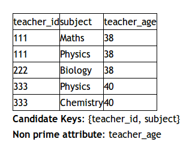

Exemple de la normalisation d’une table en 1NF - Première photo

Comme *teacher_age* dépend de *teacher_id* seulement, il n’est pas complètement dépendant de la clé primaire. Nous devons donc séparer la table comme suit:

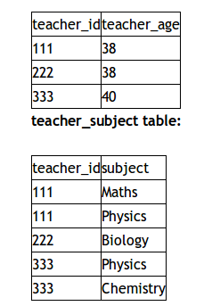

Exemple de la normalisation d’une table en 1NF - Deuxième photo

### 3.3.4 Deuxième forme normale à la troisième forme normale

Dans cette section, nous verrons comment passer de la deuxième forme normale à la troisième forme normale.

#### 3.3.4.1 Définition de la troisième forme normale (3NF)

Une relation qui est dans la première et deuxième forme normale et dans laquelle aucun attribut qui ne fait pas partie de la clé primaire est *transitivement dépendant* de la clé primaire.

#### 3.3.4.2 Technique de normalisation

Pour passer de la deuxième forme normale à la troisième, il faut enlever les dépendances transitives. Si une dépendance transitive existe, il faut l’enlever de la relation en mettant l’attribut dans une nouvelle relation avec une copie du déterminant.

Voici un exemple:

Nous avons les attributs *emp_id*, *emp_name*, *emp_zip*, *emp_state*, *emp_city* et *emp_district*. L’attribut *emp_id* est la clé primaire.

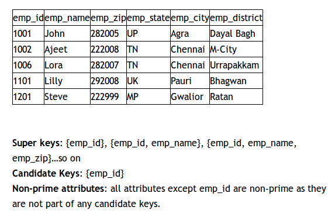

Exemple de la normalisation d’une table en 2NF - Première photo

On remarque que *emp_state*, *emp_city* et *emp_district* sont dépendants de l’attribut *emp_zip* qui lui-même est dépendant de l’attribut *emp_id*. Nous avons donc une dépendance transitive. Pour s’en débarrasser, on sépare la table de la façon suivante:

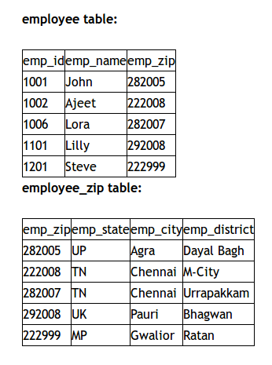

Exemple de la normalisation d’une table en 2NF - Deuxième photo

# 4 Normalisation avancée

Ce chapitre traitera de notions de normalisations avancées telles que la **forme normale Boyce-Codd**.

## 4.1 Règles d’inférence des dépendances fonctionnelles

Comme il peut y avoir beaucoup de dépendances fonctionnelles, il faut trouver des règles pour nous permettre d’identifier les plus importantes plus facilement. L’ensemble des dépendances fonctionnelles qui sont sous-entendues pour un ensemble de dépendances fonctionnelles $X$ est appelé la **fermeture** de $X$, écrit $X+$

### 4.1.1 Axiomes d’Armstrong

Les **axiomes d’Armstrong** indiquent comment des dépendances fonctionnelles peuvent être déduites de dépendences données. Soit $A$, $B$, $C$, des sous-ensembles des attributs de la relation $R$. Nous avons alors:

1. **Réflexivité**: $(B⊂A)⇒(A↦B)$
2. **Augmentation**: $(A↦B)⇒(A,C↦B,C)$
3. **Transitivité**: $(A↦B)∧(B↦C)⇒(A↦C)$

Ces règles peuvent être utilisées pour trouver $X+$. D’autres règles peuvent être dérivées des règles précédentes. Soit $D$, un autre sous-ensemble des attributs de $R$. Nous avons alors:

4. **Autodétermination**: $A↦A$
5. **Décomposition**: $(A↦B,C)⇒(A↦B)∧(A↦C)$
6. **Union**: $(A↦B)∧(A↦C)⇒(A↦B,C)$
7. **Composition**: $(A↦B)∧(C↦D)⇒(A,C↦B,D)$

### 4.1.2 Ensembles minimaux de dépendances fonctionnelles

Un ensemble de dépendances fonctionnelles $X$ est minimal s’il satisfait les exigences suivantes:

- Chaque dépendance de $X$ a un seul attribut du côté droit.
- On ne peut pas remplacer une dépendance $A↦B$ dans $X$ avec une dépendance $C↦B$, où $C$ est un sous-ensemble de $A$, et avoir un ensemble de dépendences équivalentes à $X$.
- On ne peut pas pas enlever une dépendance de $X$ et toujours avoir un ensemble de dépendances équivalent à $X$.

## 4.2 Forme normale de Boyce-Codd (BCNF)

Comme la troisième forme normale souffre encore de redondances, il existe une forme normale plus forte appelée la **forme normale de Boyce-Codd**.

### 4.2.1 Définition

Une relation est en **forme normale de Boyce-Codd** si et seulement si *tous les déterminants* sont des *clés candidates*. Il y a un potentiel de briser la forme normale de Boyce-Codd si une des deux conditions suivantes est respectée:

- La relation contient deux (ou plus) clés candidates;
- Les clés candidates se recoupent, soit qu’elles ont au moins un attribut en commun.

### 4.2.2 Technique de normalisation

Lorsqu’une dépendance fonctionnelle enfreint les contraintes pour que la relation soit en *BCNF*, il faut mettre cette dépendance dans une autre table.

## 4.3 Dépendance multi-valuée

L’existence d’une dépendance multi-valuée est dû à la première forme normale qui empêche un attribut dans un tuple d’avoir un ensemble de valeurs.

### 4.3.1 Définition

Représente une dépendence entre des attributs (par exemple, $A$, $B$ et $C$) dans une relation, tel que pour chaque valeur de $A$, il y un ensemble de valeurs $B$ et un ensemble de valeurs pour $C$. Par contre, l’ensemble de valeurs de $B$ et $C$ sont indépendants chacun des autres. On dénote une dépendance multi-valuée entre les attributs $A$, $B$ et $C$ en utilisant la notation suivante:

$A \twoheadrightarrow B$ $A \twoheadrightarrow C$

### 4.3.2 Types de dépendances multi-valuées

Une dépendance multi-valuée peut être définie comme **triviale** ou **non-triviale**.

- **Triviale**: Une dépendance multi-valuée est définie comme **triviale** si $(B⊂A)∨(A∪B=R)$.
- **Non-triviale**: Une dépendance multi-valuée est définie comme **non-triviale** si $¬((B⊂A)∨(A∪B=R))$

## 4.4 Quatrième forme normale

La **quatrième forme normale** vient corriger les problèmes que les dépendances multi-valuées apportent.

### 4.4.1 Définition

Une relation est dans la **quatrième forme normale** si et seulement si pour toutes les dépendences multi-valuées non-triviales $A \twoheadrightarrow B$, $A$ est une clé candidate de la relation.

### 4.4.2 Technique de normalisation

Il faut enlever la dépendance multi-valuée de la relation en plaçant les attributs multi-valués dans une nouvelle relation avec une copie du déterminant.

# 5 Algèbre relationnelle

Dans ce chapitre, nous verrons l’algèbre relationnelle et son utilité.

## 5.1 Définition

L’**algèbre relationnelle** est un langage théorique avec des opérations qui marchent sur une ou plusieurs relations pour définir une autre relation sans changer la relation originale.

Comme à la fois les opérandes et les résultats sont des relations, le résultat d’une opération peut être passer en paramètre à une autre opération. Cela permet aux expressions d’être imbriquées. Cette propriété s’appelle **fermeture**.

## 5.2 Opérations

L’algèbre relationnelle supporte plusieurs opérations. Dans cette section, nous allons définir différents types d’opérations. Dans ces définitions, nous avons $R$ et $S$, deux relations définies par les attributs $A=(a1,a2,…,aN)$ et $B=(b1,b2,…,bM)$ respectivement.

### 5.2.1 Opérations unaires

L’algèbre relationnelle possède deux opérations unaires: la **sélection** et la **projection**.

#### 5.2.1.1 Sélection (ou restriction)

La **sélection** s’applique sur une seule relation $R$ et définit une relation qui contient seulement les tuples de $R$ qui satisfont la condition spécifée (le *prédicat*).

On l’écrit

$$σprédicat(R)$$

où $σ$ est le nom de l’opération, $prédicat$ est le prédicat à respecter et $R$ est la relation sur laquelle l’opération est appliquée.

La sélection s’applique à l’horizontal dans une table.

#### 5.2.1.2 Projection

La **projection** s’applique sur une seule relation $R$ et définie une relation qui contient un sous-ensemble vertical de $R$. Elle extrait les valeurs des attributs spécifiés et élimine les duplicats.

On l’écrit

$$Πa1,…,an(R)$$

où $Π$ dénote le nom de l’opération, $a1,…,an$ est le nom de chacun des attributs spécifiés et $R$ est la relation sur laquelle l’opération est appliquée.

### 5.2.2 Opérations binaires

Il y a des cas où nous voulons extraire les informations de plusieurs relations à la fois. Les opérations binaires permettent de combiner les informations de deux relations à la fois.

#### 5.2.2.1 Union

L’**union** de deux relations $R$ et $S$ définit une relation qui contient tous les tuples de $R$ ou de $S$ ou bien des deux relations. Les tuples copies sont éliminés. $R$ et $S$ doivent être compatibles à l’union.

On l’écrit

$$R∪S$$

où $R$ et $S$ sont deux relations.

#### 5.2.2.2 Différence

La **différence** définit une relation qui consiste des tuples qui sont dans la relation $R$, mais pas dans la relation $S$. $R$ et $S$ doivent être compatibles à l’union.

On l’écrit

$$R−S$$

où $R$ et $S$ sont deux ensembles.

#### 5.2.2.3 Intersection

**L’intersection** définit une relation consistant de l’ensemble de tous les tuples qui sont à la fois dans $R$ et $S$. $R$ et $S$ doivent être compatibles à l’union.

On l’écrit

$$R∩S⇔R−(R−S)$$

où $R$ et $S$ sont des relations.

#### 5.2.2.4 Produit cartésien

Le **produit cartésien** définit une relation qui est la concaténation de tous les tuples de la relation $R$ avec tous les tuples de la relation $S$.

On l’écrit

$$R×S$$

où $R$ et $S$ sont des relations.

#### 5.2.2.5 Décomposition d’opérations complexes

La **décomposition d’opérations complexes** donne un nouveau nom à $S$ pour l’expression $E$, et nomme optionnellement les attributs en $a1,a2,…,an$.

On l’écrit

$$ρs(E)ou ρs(a1,a2,…,an)(E)$$

### 5.2.3 Opérations de jointure

Les **opérations de jointure** sont parmies les opérations les plus utiles de l’algèbre relationnelle. Les opérations de jointure sont équivalents à appliquer l’opération de sélection avec le prédicat de jointure au résultat du produit cartésien des deux relations d’entrée. De manière plus symbolique, si on a $F$ comme prédicat de jointure et $R$ ainsi que $S$, deux relations, nous avons que l’opération de jointure peut être définie comme:

$$σF(R×S)$$

Les types d’opérations de jointure sont les suivants:

- **Jointure *theta*** ou **($θ$-join)**
- **Equijointure**
- **Jointure naturelle**
- **Jointure externe**
- **Semi-jointure**

#### 5.2.3.1 Jointure theta ($θ$-join)

L’opération de **jointure theta** définit une relation qui contient les tuples satisfants le prédicat $F$ à partir du résultat du produit cartésien de $R$ et $S$. Le prédicat $F$ est de la forme $R.aiθS.bi$ où $θ$ peut être un des opérateur de comparaison ($<$, $≤$, $>$, $≥$, $=$, $≠$).

On l’écrit

$$R⋈FS⇔σF(R×S)$$

où $F$ est le prédicat et $R$ ainsi que $S$ sont des relations.

#### 5.2.3.2 Equijointure

L’**equijointure** est un cas particulier de $θ$-join. C’est le cas où le prédicat $F$ contient seulement l’égalité ($=$).

##### 5.2.3.2.1 Exemple d’equijointure

Nous souhaitons lister les noms et les commentaires de tous les clients qui ont vus une propriété à louer:

$$(ΠnumClient,prenom,nom(Client))⋈Client.numClient=Visite.numClient(ΠnumClient,numPropriete,commentaire(Visite))$$

#### 5.2.3.3 Jointure naturelle

La **jointure naturelle** est une equijointure des deux relations $R$ et $S$ sur tous leurs attributs communs $x$. Une occurence de chacun des attributs communs est enlevée des résultats.

On l’écrit

$$R⋈S$$

où $R$ et $S$ sont des relations.

##### 5.2.3.3.1 Exemple de jointure naturelle

Nous souhaitons énumérer les noms et les commentaires de tous les clients qui ont visité une propriété à louer:

$$(ΠnumClient,prenom,nom(Client))⋈(ΠnumClient,numPropriete,commentaire(Visite))$$

#### 5.2.3.4 Jointure externe

On l’écrit

$\begin{align*} &R \rtimes S \text{ (Jointure externe gauche) } \\ &R \ltimes S \text{ (Jointure externe droite) } \end{align*}$

##### 5.2.3.4.1 Exemple de jointure externe

Nous souhaitons produire un rapport d’état des visites de propriétés à louer:

$(\Pi_{\mathrm{numPropriete},~\mathrm{rue},~\mathrm{ville}}(\mathrm{ProprieteALouer})) \rtimes~\mathrm{Visite}$

#### 5.2.3.5 Semi-jointure

La **semi-jointure** définit une relation qui contient les tuples de $R$ qui participent dans la jointure de $R$ avec $S$ satisfaisant le prédicat $F$.

On l’écrit

$$R⊳FS⇔ΠA(R⋈FS)$$

où $A$ est l’ensemble de tous les attributs de $R$.

##### 5.2.3.5.1 Exemple de semi-jointure

On souhaite énumérer les détails complets de tous les membres du personnel qui travaillent à la filiale de Montréal:

$$Personnel⊳Personnel.numFiliale=Filiale.numFiliale(σFiliale.ville=ʹMontrealʹ(Filiale))$$

### 5.2.4 Division

Assumons que la relation $R$ est définie à partir de l’ensemble d’attributs $A$ et que la relation $S$ est définie à partir de l’ensemble d’attributs $B$ tel que $B⊆A$. Soit $C=A−B$, c’est-à-dire $C$ est l’ensemble des attributs de $R$ qui ne sont pas des attributs de $S$. Alors, l’opération de division définit une relation à partir des attributs $C$ qui consiste à l’ensemble des tuples de $R$ qui concordent avec *tous* les tuples de $S$.

On l’écrit

$$R÷S$$

que l’on peut aussi réécrire comme

$$T1←ΠC(R)T2←ΠC((T1×S)−R)T←T1−T2$$

#### 5.2.4.1 Exemple de division

On souhaite identifier tous les clients qui ont visité toutes les propriétés de trois pièces:

$$(ΠnumClient,numPropriete(Visite))÷(ΠnumPropriete(σpiece=3(ProprieteALouer)))$$

### 5.2.5 Agrégation

Applique la liste des fonctions agrégates, $AL$, à la relation $R$ pour définir une relation à partir de la liste agrégate. $AL$ contient une paire ($⟨fonction_agrégate ⟩,⟨attribut ⟩$ ou plus.

On l’écrit

$$ℑAL(R)$$

Les principales fonctions agrégates sont les suivantes:

- *COUNT*: Retourne le nombre de valeurs de l’attribut associé.
- *SUM*: Retourne la somme des valeurs de l’attribut associé.
- *AVG*: Retourne la moyenne des valeurs de l’attribut associé.
- *MIN*: Retourne la plus petite valeur de l’attribut associé.
- *MAX*: Retourne la plus grande valeur de l’attribut associé.

#### 5.2.5.1 Exemple d’agrégation

On souhaite trouver le salaire minimum, maximum et moyen des employés:

$$ρR(monMin,monMax,maMoyenne)ℑMINsalaire,MAXsalaire,AVGsalaire(Personnel)$$

### 5.2.6 Regroupement

Groupe les tuples de la relation $R$ par les attributs de groupement, $GA$, et applique ensuite la liste de fonctions agrégates $AL$ pour définir une nouvelle relation. $AL$ contient une paire ($⟨fonction_agrégate ⟩,⟨attribut ⟩$ ou plus. La relation résultante contient les attributs de groupement $GA$ avec le résultat de chacune des fonctions agrégates.

On l’écrit

$$GAℑAL(R)$$

La forme générale de l’opération de regroupement est la suivante:

$$a1,a2,…,anℑ⟨Apap⟩,⟨Aqaq⟩,…,⟨Azaz⟩(R)$$

où $R$ est une relation quelconque, $a1,a2,…,an$ sont des attributs de $R$, $ap,aq,…,az$ sont d’autres attributs de $R$ et $Ap,Aq,…,Az$ sont des fonctions agrégates. Les tuples de $R$ sont partitionnés de sorte que:

- tous les tuples dans un groupe on la même valeur pour $a1,a2,…,an$;
- les tuples dans différents groupes ont des valeurs différentes pour $a1,a2,…,an$.

#### 5.2.6.1 Exemple de regroupement

Nous souhaitons trouver le nombre d’employés qui travaillent dans chaque filiale et calculer la somme de leurs salaires:

$$ρR(numFiliale,monCompte,maSomme)numFilialeℑCOUNTnumPersonnel,SUMsalaire(Personnel)$$

# 6 Structured Query Language (SQL) : Manipulation des données

Dans ce chapitre, nous aborderons des notions sur le **Structured Query Language** ou **SQL**.

## 6.1 Objectifs du SQL

Idéalement, un langage de bases de données devrait permettre de

- créer la base de données et les structures des relations
- faire des opérations de gestion de données telles que l’insertion, la modification and la supression de données des relations
- faire des requêtes à la fois simples et complexes

Le langage doit être simple; sa syntaxe et sa structure de commandes doivent être simples à apprendre. Le langage doit aussi être portable, c’est-à-dire qu’il doit être conforme à des standards pour que nous puissions utiliser les mêmes commandes d’un système de gestion de bases de données à un autre.

## 6.2 Informations sur le SQL

Le SQL est un **langage orienté transformation** ce qui veut dire que c’est un langage qui a été développé pour utiliser des relations pour transformer des entrées en des sorties demandées. Le SQL possède deux parties majeurs:

- Un **langage de définition des données (DDL)** pour définir la structure de la base de données et contrôler l’accès aux données.
- Un **langage de manipulation des données (DML)** pour aller chercher et mettre à jour les données.

Le SQL est un langage qui n’est pas procédural. Nous spécifions les données dont nous avons besoin plutôt que comment aller les chercher. Autrement dit, nous n’avons pas à nous occuper des méthodes d’accès aux données: SQL le fait pour nous.

### 6.2.1 Terminalogie

Les standards ISO du SQL n’utilisent pas les termes formels *relations*, *attributs* et *tuples*. Ils utilisent plutôt les mots *tables*, *colonnes* et *rangées*.

## 6.3 Écrire des commandes SQL

Une déclaration SQL consiste de **mots réservés** et **de mots définis par l’utilisateur**. Les mots réservés font partis du langage et ont un sens fixes alors que les mots définis par l’utilisateur font références à des objets de la base de données comme les tables, colonnes, vues, indexes, etc. Les déclarations SQL ne sont pas sensibles à la casse. La seule exception est que les caractères litéraux doivent être écrits comme ils apparaissent dans la base de données.

### 6.3.1 Convention de code

La convention du cours utilise en partie la **forme de Backus Naur (BNF)**. La convention que nous allons utiliser est donc la suivante:

- les mots réservés sont écrits en minuscules;
- les mots définis par l’utilisateur sont en majuscules;
- la bar vertical ($∣$) indique un choix parmi des alternatives;
- les accolades indiquent un élément requis;
- les crochets indiquent un élément optionnel;
- les points de suspension indique une répétition optionnelle d’un objet zéro ou plusieurs fois.

### 6.3.2 Manipulation des données

Cette section traite des différentes expressions du DML du SQL:

```sql
    select -- pour aller chercher des données dans la base de données
    insert -- pour insérer des données dans une table
    update -- pour mettre à jour des données dans une table
    delete -- pour effacer des données d'une table
```

Pour les explications des expressions, nous allons utiliser les tables suivantes:

Cas d’étude *DreamHome*

| Branch | (**Branch**, street, city, postcode) |
| --- | --- |
| Staff | (**staffNo**, fName, lName, position, sex, DOB, salary, branchNo) |
| PropertyForRent | (**propertyNo**, street, city, postcode, type, rooms, rent, |
|  | ownerNo, staffNo, branchNo) |
| Client | (**clientNo**, fName, lName, telNo, prefType, maxRent, eMail) |
| PrivateOwner | (**ownerNo**, fName, lName, address, telNo, eMail, password) |
| Viewing | (**clientNo**, propertyNo, viewDate, comment) |

### 6.3.3 Litéraux

Les litéraux sont des constantes qui sont utilisées dans des expressions SQL. Les chaines de caractères litérales doivent être entourées de guillemets simples et les litéraux numériques ne doivent pas avoir de guillemets.

Un exemple d’insertion de litéraux dans une table pourrait ressembler à

```sql
    insert into PropertyForRent(propertyNo, street, city, postcode, type,
                                rooms, rent, ownerNo, staffNo, branchNo)
    values ('PA14', '16 Holhead', 'Aberdeen', 'AB7 5SU', 'House', 6, 650.00,
            'CO46', 'SA9', 'B007');
```

### 6.3.4 SELECT

L’expression `select` est utilisé pour aller chercher et afficher des données d’une ou plusieurs tables de bases de données. Elle permet de faire l’équivalent des opérations de *sélection*, *projecture* et de *jointure* de l’algèbre relationnelle.

L’expression `select` a la forme suivante:

```sql
    select      [distinct | all] {* | [columnExpression [as newName]] [,...]}
    from        TableName [alias] [,...]
    [where      condition]
    [group by   columnList] [having condition]
    [order by   columnList]
```

où chacune des expressions a la signification suivante:

```sql
    from        -- Table(s) à utiliser
    where       -- Filtre rangées selon une condition
    group by    -- Forme des groupes de rangées avec des mêmes valeurs de colonnes
    having      -- Filtre les groupes selon une condition
    select      -- Spécifie les colonnes qui vont apparaître dans la sortie
    order by    -- Spécifie l'ordre d'affichage
```

Il est important de retenir que l’ordre des clauses de l’expression `select` ne peut être changé et que les deux seules clauses obligatoires sont les deux premières: `select` et `from`. Les autres clauses sont optionnelles. Le résultat d’une expression `select` est une autre table.

L’expression `select` ne peut seulement contenir que:

- des noms de colonnes;
- des fonctions agrégates;
- des constantes;
- une expression combinant les points précédents.

#### 6.3.4.1 Exemples d’utilisation du SELECT

Dans tous les exemples suivants, nous allons nous servir de la table *DreamHome*.

##### 6.3.4.1.1 Aller chercher toutes les colonnes et rangées

Nous voulons aller chercher toutes les informations sur le personnel.

Comme il n’y a pas de conditions, nous n’avons pas besoin d’un `where`. Nous pouvons donc écrire cette requête comme

```sql
    select staffNo, fName, lName, position, sex, DOB, salary, branchNo
    from Staff;
```

Comme nous sélectionnons toutes les colonnes, nous pourrions réécrire cette requête comme

```sql
    select *
    from Staff;
```

Nous obtiendrons la table suivante:

Résultat de la requête

| staffNo | fName | lName | position | sex | DOB | salary | branchNo |
| --- | --- | --- | --- | --- | --- | --- | --- |
| SL21 | John | White | Manager | M | 1-Oct-45 | 30000.00 | B005 |
| SG37 | Ann | Beech | Assistant | F | 10-Nov-60 | 12000.00 | B003 |
| SG14 | David | Ford | Supervisor | M | 24-Mar-58 | 18000.00 | B003 |
| SA9 | Mary | Howe | Assistant | F | 19-Feb-70 | 9000.00 | B007 |
| SG5 | Susan | Brand | Manager | F | 3-Jun-40 | 24000.00 | B003 |
| SL41 | Julie | Lee | Assistant | F | 13-Jun-65 | 9000.00 | B005 |

##### 6.3.4.1.2 Aller chercher des colonnes spécifiques et toutes les rangées

On veut la liste des salaires de tous les employés en montrant seulement les numéros d’employés, les prénoms, les noms de famille et les détails du salaire.

Cette requête serait écrite comme

```sql
    select staffNo, fName, lName, salary
    from Staff;
```

Ce qui nous donnerait la table suivante:

Résultat de la requête

| staffNo | fName | lName | salary |
| --- | --- | --- | --- |
| SL21 | John | White | 30000.00 |
| SG37 | Ann | Beech | 12000.00 |
| SG14 | David | Ford | 18000.00 |
| SA9 | Mary | Howe | 9000.00 |
| SG5 | Susan | Brand | 24000.00 |
| SL41 | Julie | Lee | 9000.00 |

##### 6.3.4.1.3 Utiliser DISTINCT

Lorsqu’on fait un `select` sur une table, les copies sont conservés. Le mot clé `distinct` permet d’éliminer les copies. Par exemple,

```sql
    select distinct propertyNo
    from Viewing;
```

va seulement retourner un seul numéro de propriété par copie.

##### 6.3.4.1.4 Champs calculés

Nous voulons avoir la liste de tous les salaires mensuels de tous les employés, montrer les numéros d’employé, les prénoms, les noms de famille et les détails des salaires.

Il est possible d’ajouter des opérations arithmétiques à des expressions SQL. Ainsi, pour construire la requête demandée, nous pourrions écrire

```sql
    select staffNo, fName, lName, salary/12
    from Staff;
```

ou, avec un alias,

```sql
    select staffNo, fName, lName, salary/12 as monthlySalary
    from Staff;
```

#### 6.3.4.2 Sélection de rangées (WHERE)

Avec l’expression `where`, nous pouvons sélectionner des rangées spécifiques. Pour ce faire, nous utilisons le mot clé `where` suivi d’un prédicat. Les prédicats de base sont les suivants:

- *Comparaison*: Compare la valeur d’une expression avec la valeur d’une autre expression.
- *Recherche d’écart*: Teste si la valeur d’une expression se retrouve dans une certaine plage de valeurs.
- *Appartenance à un ensemble*: Teste si la valeur d’une expression est égale à celle d’un ensemble de valeurs.
- *Correspondance à un masque*: Teste si une chaîne de caractères correspond à un modèle spécifique.
- *Null*: Teste si la colonne a une valeur nulle (inconnue).

Les opérateurs de comparaison suivants sont disponibles dans le langage SQL:

```
    =       égal
    <>      pas égale
    <       plus petit que
    <=      plus petit ou égal
    >       plus grand que
    >=      plus grand ou égal
```

Il y aussi les opérateurs logiques `AND`, `OR` et `NOT` qui sont disponibles. Les prioriétés des opérations sont les suivantes:

- Une expression est évaluée de gauche à droite.
- Les sous-expressions entre parenthèses sont évaluées en premier.
- Les `NOT` sont évalués avant les `AND` et les `OR`.
- Les `AND` sont évalués avant les `OR`.

Il est important de retenir que les fonctions d’agrégation ne peuvent pas être utilisées dans une clause `WHERE`.

##### 6.3.4.2.1 Exemples d’utilisation du WHERE

Dans cette section, nous allons voir des exemples d’utilisation de la clause `where`.

###### 6.3.4.2.1.1 Prédicat de comparaison

On souhaite avoir la liste de tous les employés avec un salaire plus grand que 10000$.

Nous pouvons donc utiliser la clause `where` de la manière suivante:

```sql
    select staffNo, fName, lName, position, salary
    from Staff
    where salary > 10000;
```

Ce bout de code va créer une table dont les rangées correspondent aux rangées de la table initiale dont le salaire des employés est plus grand que 10000$.

###### 6.3.4.2.1.2 Prédicat de comparaison composé

On souhaite avoir la liste de toutes les adresses des filiales de Londres et Glasgow.

Nous pouvons donc utiliser la clause `where` de la manière suivante:

```sql
    select *
    from Branch
    where city = 'London' or city = 'Glasgow';
```

Cela va créer une table dont les rangées correspondent aux rangées de la table initiale où la ville était soit Londres ou Glasgow.

###### 6.3.4.2.1.3 Prédicat de recherche d’écart (BETWEEN/NOT BETWEEN)

On souhaite avoir tous les employés dont le salaire se situe entre 20000$ et 30000$.

Nous pouvons donc utiliser la clause `where` de la manière suivante:

```sql
    select staffNo, fName, lName, position, salary
    from Staff
    where salary between 20000 and 30000;
```

Cela va créer une table dont les rangées correspondent aux rangées de la table initiale dont le salaire des employés était entre 20000 et 30000.

Nous aurions aussi pu écrire

```sql
    select staffNo, fName, lName, position, salary
    from Staff
    where salary >= 20000 and salary <= 30000;
```

###### 6.3.4.2.1.4 Prédicat d’appartenance à un ensemble (IN/NOT IN)

On souhaite avoir tous les employés qui sont des managers et des superviseurs.

Nous pouvons donc utiliser la clause `where` de la manière suivante:

```sql
    select staffNo, fName, lName, position
    from Staff
    where position in ('Manager', 'Supervisor');
```

Cela va créer une table dont les rangées correspondent aux rangées de la table initiale dans lesquelles le poste des employés était soit un manager ou un superviseur.

Nous aurions aussi pu écrire

```sql
    select staffNo, fName, lName, position
    from Staff
    where position = 'Manager' or position = 'Supervisor';
```

###### 6.3.4.2.1.5 Prédicat de correspondance à un masque (LIKE/NOT LIKE)

Nous voulons trouver tous les propriétaires qui ont la chaîne de caractères ‘Glasgow’ dans leur adresse.

Le SQL possède deux symboles pour trouver des correspondances entre des chaînes de caractères:

- Le caractère % représente une séquence de zéro caractère ou plus.
- Le caractère _ représente n’importe quel caractère.

Tous les autres caractères se représentent eux-mêmes.

Ainsi, notre requête pour résoudre notre problème serait la suivante:

```sql
    select ownerNo, fName, lName, address, telNo
    from PrivateOwner
    where address like '%Glasgow%'; -- N'importe quelle chaine, tant qu'elle contient 'Glasgow'
```

###### 6.3.4.2.1.6 Prédicat de recherche de NULL (IS NULL/IS NOT NULL)

Nous voulons avoir les détails sur toutes les propriétés PG4 où un commentaire n’a pas été fourni.

Nous pouvons donc utiliser la clause de la manière suivante:

```sql
    select clientNo, viewDate
    from Viewing
    where propertyNo = 'PG4' and comment is null;
```

#### 6.3.4.3 Trier les résultats (ORDER BY)

La clause `ORDER BY` permet de classer des éléments selon un certain ordre. La clause `ORDER BY` reçoit en arguments la liste des identifiants des colonnes séparés par des virgules à partir desquels nous voulons trier. Il y a deux ordres de tri: en ordre croissant (ASC) et en ordre décroissant (DESC). La clause `ORDER BY` doit toujours être la dernière clause d’une expression `SELECT`. Le premier élément qui apparait dans la clause est appelé la **clé majeure de tri**. C’est elle qui va décider de l’ordre de tri général. Si les éléments de la colonne sont uniques, un élément de tri de va être suffisant. Sinon, on peut rajouter des éléments à la clause pour spécifier l’ordre de tri. On appelle tous les éléments qui apparaissent après la clé majeure de tri des **clés mineures de tri**

##### 6.3.4.3.1 Exemples d’utilisation du ORDER BY

Dans cette section, nous verrons des exemples d’utilisation de la clause `ORDER BY`.

###### 6.3.4.3.1.1 Tri avec une seule colonne

Nous voulons la liste du salaire des employés en ordre décroissant.

Nous pourrions donc écrire la clause suivante:

```sql
    select staffNo, fName, lName, salary
    from Staff
    order by salary desc;
```

###### 6.3.4.3.1.2 Tri avec plusieurs colonnes

Nous voulons avoir la liste des propriétés triées par le type des propriétés.

Nous pourrions écrire la clause suivante:

```sql
select propertyNo, type, rooms, rent
from PropertyForRent
order by type;
```

On obtiendrait alors la table suivante:

| propertyNo | type | rooms | rent |
| --- | --- | --- | --- |
| PL94 | Flat | 4 | 400 |
| PG4 | Flat | 3 | 350 |
| PG36 | Flat | 3 | 375 |
| PG16 | Flat | 4 | 450 |
| PA14 | House | 6 | 650 |
| PG21 | House | 5 | 600 |

Par contre, si on précise une clé mineure de tri avec la clause suivante:

```sql
select propertyNo, type, rooms, rent
from PropertyForRent
order by type, rent desc;
```

On obtiendrait la table suivante:

| propertyNo | type | rooms | rent |
| --- | --- | --- | --- |
| PG16 | Flat | 4 | 450 |
| PL94 | Flat | 4 | 400 |
| PG36 | Flat | 3 | 375 |
| PG4 | Flat | 3 | 350 |
| PA14 | House | 6 | 650 |
| PG21 | House | 5 | 600 |

#### 6.3.4.4 Fonctions SQL d’agrégation

Les fonctions d’agrégation permettent d’effectuer des opérations sur des données. Il existe 5 types de fonctions d’agrégation définies par les standards ISO:

- `COUNT`: Retourne le nombre de valeurs dans la colonne spécifiée.
- `SUM`: Retourne la somme des valeurs dans la colonne spécifiée.
- `AVG`: Retourne la moyenne des valeurs dans la colonne spécifiée.
- `MIN`: Retourne la plus petite valeur dans la colonne spécifiée.
- `MAX`: Retourne la plus grande valeur dans la colonne spécifiée.

Les fonctions `AVG` et `SUM` peuvent seulement être utilisées sur des colonnes numériques. Toutes les fonctions éliminent les *nulls* avant d’effectuer leurs calculs. Il y a seulement `COUNT(*)` qui n’élimine pas les *nulls* avant de faire ses opérations.

Si on veut éliminer les copies, il faut utiliser le mot clé `DISTINCT` avant le nom de la colonne dans la fonction. Si on spécifie le mot clé `ALL` devant le nom des colonnes, on indique qu’on permet les copies.

##### 6.3.4.4.1 Exemples d’utilisation des fonctions SQL d’agrégation

Dans cette section, nous verrons des exemples d’utilisation des fonctions SQL d’agrégation.

Nous allons donc avoir la clause suivante:

```sql
    select staffNo count(salary)
    from Staff;
```

###### 6.3.4.4.1.2 Utilisation de `COUNT(DISTINCT)`

Nous souhaitons savoir combien de propriétés différentes ont été vues en mai 2013.

Nous allons donc avoir la clause suivante:

```sql
    select count(distinct propertyNo) as myCount
    from Viewing
    where viewDate between '1-May-13' and '31-May-13';
```

###### 6.3.4.4.1.3 Utilisation de `COUNT` et `SUM`

Nous souhaitons trouver le nombre total de managers et la somme de leurs salaires.

Nous allons donc avoir la clause suivante:

```sql
    select count(staffNo) as myCount, sum(salary) as mySum
    from Staff
    where position = 'Manager';
```

###### 6.3.4.4.1.4 Utilisation de `MIN`, `MAX` et `AVG`

Nous souhaitons trouver le salaire minimum et maximum ainsi que la moyenne des salaires des employés.

Nous allons donc avoir la clause suivante:

```sql
    select min(salary) as myMin, max(salary) as myMax, avg(salary) as myAvg
    from Staff;
```

#### 6.3.4.5 Grouper les résultats (`GROUP BY`)

Lorsqu’on veut grouper des résultats, on se sert de la clause `GROUP BY`. Il est important de retenir que toutes les noms de colonnes qui apparaissent dans la clause `SELECT` doivent apparaître dans la clause `GROUP BY`, mais toutes les colonnes de `GROUP BY` ne sont pas obligées d’être dans la clause `SELECT`. La seule exception est si le nom de la colonne est seulement utilisé dans une fonction d’agrégation.

Aussi, lorsqu’une clause `WHERE` est utilisée avec la clause `GROUP BY`, la clause `WHERE` est appliquée en premier.

##### 6.3.4.5.1 Exemple d’utilisation de `GROUP BY`

Nous souhaitons trouver le nombre d’employés dans chaque branche ainsi que la somme de leurs salaires.

Nous allons donc avoir la clause suivante:

```sql
    select branchNo, count(staffNo) as myCount, sum(salary) as mySum
    from Staff
    group by branchNo
    order by branchNo;
```

Nous aurons alors la table suivante:

| branchNo | myCount | mySum |
| --- | --- | --- |
| B003 | 3 | 54000.00 |
| B005 | 2 | 39000.00 |
| B007 | 1 | 9000.00 |

Nous aurions aussi pu réécrire cette requête comme

```sql
    select branchNo, (select count(staffNo) as myCount
                      from Staff s
                      where s.branchNo = b.branchNo),
                     (select sum(salary) as mySum
                      from Staff s
                      where s.branchNo = b.branchNo)
    from Branch b
    order by branchNo;
```

#### 6.3.4.6 Restreindre les groupements (`HAVING`)

La clause `HAVING` a été conçue pour être utilisée avec la clause `GROUP BY` afin de restreindre les groupes qui apparaissent dans la table de résultats finale. Les noms de colonnes qui se retrouvent dans la clause `HAVING` doivent se retrouver dans la clause `GROUP BY`. La clause `HAVING` doit toujours inclure une fonction d’agrégation.

La clause `HAVING` n’est pas essentielle au langage SQL; le langage serait capable d’effectuer les mêmes opérations sans la clause `HAVING`.

##### 6.3.4.6.1 Exemple d’utilisation de `HAVING`

Nous souhaitons trouver le nombre d’employés qui travaillent dans chaque branche et la somme de leur salaire pour chaque branche qui a plus qu’un employé.

Nous aurons donc la requête suivante:

```sql
    select branchNo, count(staffNo) as myCount, sum(salary) as mySum
    from Staff
    group by branchNo
    having count(staffNo) > 1
    order by branchNo;
```

Nous aurons donc la table suivante:

| branchNo | myCount | mySum |
| --- | --- | --- |
| B003 | 3 | 54000.00 |
| B005 | 2 | 39000.00 |

#### 6.3.4.7 Sous-requêtes

Une expression `SELECT` peut se retrouver dans une autre expression `SELECT`. Le résultat de ce `SELECT` sera alors utilisé pour déterminer le contenu du résultat final. Un `SELECT` peut aussi être utilisé dans une clause `WHERE` et `HAVING`. On l’appelle alors une **sous-requête**. Il y a trois types de sous-requêtes:

- **Sous-requête scalaire**: Retourne une seule colonne et une seule ligne, soit une seule valeur. Utilisée lorsqu’une seule valeur est nécessaire.
- **Sous-requête de ligne**: Retourne plusieurs colonne, mais une seule ligne. Utilisée surtout dans les prédicats.
- **Sous-requête de table**: Retourne une ou plusieurs colonnes et plusieurs lignes. Utilisée lorsqu’une table est requise.

Les règles suivantes s’appliquent aux sous-requêtes:

- La clause `ORDER BY` ne peut pas être utilisée dans une sous-requête.
- Il ne doit y avoir qu’une seule colonne ou expression passée en argument au `SELECT` d’une sous-requête sauf si le mot clé `EXISTS` est utilisé.
- Par défaut, les noms de colonnes dans une sous-requête réfère à celles de la table de la clause `FROM` de la sous-requête.
- Quand une sous-requête est utilisée comme opérande dans une comparaison, elle doit toujours être à droite dans la comparaison.

##### 6.3.4.7.1 Mots clés `ANY` et `ALL`

Les mots clés `ANY` et `ALL` peuvent être utilisés avec les sous-requêtes qui produisent une seule colonne. Si la sous-requête est précédée du mot clé `ALL`, la condition va être vraie seulement si elle est satisfaite par toutes les valeurs de la sous-requête. Si la sous-requête est précédée par le mot clé `ANY`, la condition va être vraie si elle satisfaite par au moins une valeur de la sous-requête. Le mot clé `SOME` est équivalent au mot clé `ANY`.

##### 6.3.4.7.2 Exemple d’utilisation de sous-requêtes

Dans cette section, nous verrons des exemples d’utilisation de sous-requêtes.

###### 6.3.4.7.2.1 Sous-requête avec l’opérateur d’égalité

Nous souhaitons trouver le personnel qui travaille dans la branche ‘163 Main St’.

Nous aurons donc la requête suivante:

```sql
    select staffNo, fName, lName, position
    from Staff
    where branchNo = (select branchNo
                      from Branch
                      where street = '163 Main St');
```

La sous-requête va trouver le numéro de la branche qui correspond à la branche dont le nom de la rue est ‘163 Main St’. Cela va retourner une seule valeur. Il s’agit donc d’une sous-requête scalaire.

###### 6.3.4.7.2.2 Sous-requête avec une fonction d’agrégation

Nous souhaitons trouver tous les employés dont le salaire est plus grand que la moyenne des salaires et montrer de combien leur salaire est plus grand que la moyenne.

Nous aurons donc la requête suivante:

```sql
    select staffNo, fName, lName, position,
           salary - (select avg(salary) from Staff) as salDiff
    from Staff
    where salary > (select avg(salary) from Staff);
```

Nous ne pouvons pas utiliser `avg(salary)` direct dans la clause `WHERE`, car les fonctions d’agrégation ne sont pas permises dans une clause `WHERE`.

###### 6.3.4.7.2.3 Utilisation de `IN`

Nous souhaitons avoir toutes les propriétés qui sont administrées par les employés qui travaillent à la branche à ‘163 Main St’.

Nous aurons donc la requête suivante:

```sql
    select propertyNo, street, city, postcode, type, rooms, rent
    from PropertyForRent
    where staffNo in (select staffNo
                      from Staff
                      where branchNo = (select branchNo
                                        from Branch
                                        where street = '163 Main St'));
```

La dernière sous-requête selectionne le numéro de la branche qui se trouve à ‘163 Main St’. L’avant-dernière sous-requête sélectionne les employés qui travaille à cette branche. Ensuite, comme cette requête retourne plusieurs valeurs, nous utilisons le mot clé `IN`.

Nous obtenons donc la table suivante:

| propertyNo | street | city | postcode | type | rooms | rent |
| --- | --- | --- | --- | --- | --- | --- |
| PG16 | 5 Novar Dr | Glasgow | G12 9AX | Flat | 4 | 450 |
| PG36 | 2 Manor Rd | Glasgow | G32 4QX | Flat | 3 | 375 |
| PG21 | 18 Dale Rd | Glasgow | G12 | House | 5 | 600 |

###### 6.3.4.7.2.4 Utilisation de `ANY`/`SOME`

Nous souhaitons trouver tous les employés dont le salaire est plus grand que le salaire d’au moins un employé à la branche B003.

Nous aurons donc la requête suivante:

```sql
    select staffNo, fName, lName, position, salary
    from Staff
    where salary > some(select salary
                        from Staff
                        where branchNo = 'B003');
```

Nous obtiendrons donc la table suivante:

| staffNo | fName | lName | position | salary |
| --- | --- | --- | --- | --- |
| SL21 | John | White | Manager | 30000.00 |
| SG14 | David | Ford | Supervisor | 18000.00 |
| SG5 | Susan | Brand | Manager | 24000.00 |

###### 6.3.4.7.2.5 Utilisation de `ALL`

Nous souhaitons trouver tous les employés dont le salaire est plus grand que le salaire de tous les employés à la branche B003.

Nous aurons donc la requête suivante:

```sql
    select staffNo, fName, lName, position, salary
    from Staff
    where salary > all(select salary
                       from Staff
                       where branchNo = 'B003');
```

Nous obtiendrons donc la table suivante:

| staffNo | fName | lName | position | salary |
| --- | --- | --- | --- | --- |
| SL21 | John | White | Manager | 30000.00 |

#### 6.3.4.8 Requêtes multi-tables

Pour combiner des colonnes de plusieurs tables dans une seule table, nous devons utiliser une opération de **jointure**. L’opération de jointure du SQL combine les informations de deux tables en formant des paires de rangées liés. Ces paires de rangées sont celles où les colonnes correspondantes des deux tables ont la même valeur.

Pour faire une opération de jointure, il suffit d’inclure plus qu’une table dans la clause `FROM`. On sépare les noms de tables par des virgules. On peut aussi utiliser des alias. Pour ce faire, il suffit d’ajouter un espace après le nom de la table et mettre le nom de l’alias qu’on veut utiliser.

##### 6.3.4.8.1 Calculer une jointure

Une jointure est un sous-ensemble du produit cartésien. Le produit cartésien de deux tables est une autre table avec toutes les paires de rangées possibles des deux tables. Si on fournit deux tables sans clause `WHERE`, le produit cartésien des deux tables sera calculé.

Les standards ISO ont établi une forme spéciale du `SELECT` pour le produit cartésien:

```
    SELECT [DISTINCT | ALL] {* | columnList}
    FROM TableName1 CROSS JOIN TableName2
```

La procédure pour effectuer une jointure avec un `SELECT` est la suivante:

1. Faire le produit cartésien avec les tables de la clause `FROM`.
2. S’il y a une clause `WHERE`, il faut appliquer la condition de recherche sur chacune des rangées du résultat du produit cartésien de sorte de ne retenir que les rangées qui satisfont la condition.
3. Pour chacune des rangées restantes, il faut déterminer la valeur de chacun des éléments dans la liste des éléments du `SELECT` afin de produire une seule rangée dans la table résultante.
4. S’il y a le mot clé `DISTINCT`, il faut éliminer toutes les copies de rangées de la table résultante.
5. S’il y a une clause `ORDER BY`, il faut trier la table selon la condition émise.

##### 6.3.4.8.2 Jointures externes

Les jointures vues jusqu’à présent gardent seulement les rangées qui correspondent entre les tables. Si une rangée ne correspond à aucune autre rangée, elle est omise du résultat.

- **Jointure externe gauche**
- **Jointure externe droite**
- **Jointure externe complète**

##### 6.3.4.8.3 Mots clés `EXISTS` et `NOT EXISTS`

Les mots clés `EXISTS` et `NOT EXISTS` ont été conçus pour seulement fonctionner avec les sous-requêtes. Ils produisent une valeur de vrai ou faux. `EXISTS` est vrai seulement s’il existe au moins une rangée dans la table résultante retournée par la sous-requête. `EXISTS` retourne faux si la sous-requête retourne une table résultante vide.

##### 6.3.4.8.4 Combiner les tables résultantes (`UNION`, `INTERSECT`, `EXCEPT`)

Dans le langage SQL, nous pouvons utiliser les opérations d’*union*, d’*intersection* et de *différence* pour combiner les résultats de deux ou plusieurs requêtes dans une seule table résultante:

- L’**union** de deux tables, $A$ et $B$, est une table contenant toutes les rangées qui sont soit dans la table $A$ ou dans la table $B$.
- L’**intersection** de deux tables, $A$ et $B$, est une table contenant toutes les rangées qui sont à la fois dans la table $A$ et $B$.
- La **différence** de deux tables, $A$ et $B$, est une table contenant toutes les rangées qui sont dans la table $A$, mais pas dans la table $B$.

Pour pouvoir se servir de ces opérations, les tables doivent être compatibles à l’union, c’est-à-dire avoir le même nombre de colonnes et que les colonnes ont la même longueur et le même type.

La façon d’utiliser ces opérations dans le langage se fait de la manière suivante:

```
    operator[ALL][CORRESPONDING [BY {column1, [,...]}]]
```

##### 6.3.4.8.5 Exemples d’opérations de jointure

Dans cette section, nous verrons des exemples d’opérations de jointure.

###### 6.3.4.8.5.1 Opération de jointure simple

Nous souhaitons avoir le nom de tous les clients qui ont vu une propriété avec tous les commentaires associés.

Nous aurons donc la requête suivante:

```sql
    select c.clientNo, fName, lName, propertyNo, comment
    from Client c, Viewing v
    where c.clientNo = v.clientNo;
```

###### 6.3.4.8.5.2 Trier une opération de jointure

Pour chaque branche, nous souhaitons avoir la liste de tous les numéros d’employés et le nom des employés qui administrent des propriétés et les propriétés qu’ils administrent.

Nous aurons donc la requête suivante:

```sql
    select s.branchNo, s.staffNo, fName, lName, propertyNo
    from Staff s, PropertyForRent p
    where s.staffNo = p.staffNo
    order by s.branchNo, s.staffNo, propertyNo;
```

###### 6.3.4.8.5.3 Opération de jointure sur trois tables

Pour chaque branche, nous souhaitons avoir la liste des numéros de personnel ainsi que le nom du personnel qui administre des propriétés y compris la ville dans laquelle chaque branche est située et les propriétés que le personnel administre.

Nous aurons donc la requête suivante:

```sql
    select b.branchNo, b.city, s.staffNo, fName, lName, propertyNo
    from Branch b, Staff s, PropertyForRent p
    where b.branchNo = s.branchNo and s.staffNo = p.staffNo
    order by b.branchNo, s.staffNo, propertyNo;
```

###### 6.3.4.8.5.4 Multiples groupements de colonnes

Nous souhaitons trouver le nombre de propriétés administrées par chaque des membres du personnel ainsi que le numéro de branche de chaque membre du personnel.

Nous aurons donc la requête suivante:

```sql
    select s.branchNo, s.staffNo, count(*) as myCount
    from Staff s, PropertyForRent p
    where s.staffNo = p.staffNo
    group by s.branchNo, s.staffNo
    order by s.branchNo, s.staffNo;
```

###### 6.3.4.8.5.5 Jointure externe gauche

Nous souhaitons trouver toutes les branches et toutes les propriétés qui sont dans la même ville.

Nous aurons donc la requête suivante:

```sql
    select b.*, p.*
    from Branch1 b left join PropertyForRent1 p on b.bCity = p.pCity;
```

La table résultante sera la suivante:

| branchNo | bCity | propertyNo | pCity |
| --- | --- | --- | --- |
| B003 | Glasgow | PG4 | Glasgow |
| B004 | Bristol | null | null |
| B002 | London | PL94 | London |

###### 6.3.4.8.5.6 Jointure externe droite

Nous souhaitons trouver toutes les propriétés et toutes les branches qui sont dans la même ville.

Nous aurons alors la requête suivante:

```sql
    select b.*, p.*
    from Branch1 b right join PropertyForRent1 p on b.bCity = p.pCity;
```

La table résultante sera la suivante:

| branchNo | bCity | propertyNo | pCity |
| --- | --- | --- | --- |
| null | null | PA14 | Aberdeen |
| B003 | Glasgow | PG4 | Glasgow |
| B002 | London | PL94 | London |

###### 6.3.4.8.5.7 Jointure externe complète

Nous souhaitons trouver toutes les branches et propriétés qui sont dans la même ville avec toutes les branches ou propriétés qui n’ont aucune correspondance.

Nous aurons alors la requête suivante:

```sql
    select b.*, p.*
    from Branch1 b full join PropertyForRent1 p on b.bCity = p.pCity;
```

La table résultant sera la suivante:

| branchNo | bCity | propertyNo | pCity |
| --- | --- | --- | --- |
| null | null | PA14 | Aberdeen |
| B003 | Glasgow | PG4 | Glasgow |
| B004 | Bristol | null | null |
| B002 | London | PL94 | London |

###### 6.3.4.8.5.8 Requête utilisant `EXISTS`

Nous souhaitons trouver tout le personnel qui travaille à la branche de Londres.

Nous aurons alors la requête suivante:

```sql
    select staffNo, fName, lName, position
    from Staff s
    where exists (select *
                  from Branch b
                  where s.branchNo = b.branchNo and city = 'London');
```

###### 6.3.4.8.5.9 Utiliser `UNION`

Nous souhaitons avoir la liste de toutes les villes qui sont une branche soit une propriété.

Nous aurons alors la requête suivante:

```sql
    (select city
     from Branch
     where city is not null)
     union
    (select city
     from PropertyForRent
     where city is not null);
```

ou

```sql
    (select *
     from Branch
     where city is not null)
     union corresponding by city
    (select *
     from PropertyForRent
     where city is not null);
```

###### 6.3.4.8.5.10 Utiliser `INTERSECT`

Nous souhaitons avoir la liste des villes où il y a à la fois une branche et une propriété.

Nous aurons alors la requête suivante:

```sql
    (select city
     from Branch)
     intersect
    (select city
     from PropertyForRent);
```

ou

```sql
    (select *
     from Branch)
     intersect corresponding by city
    (select *
     from PropertyForRent);
```

Nous pourrions également réécrire ces requêtes sans l’opérateur `INTERSECT`:

```sql
    select distinct b.city
    from Branch b, PropertyForRent p
    where b.city = p.city;
```

ou

```sql
    select distinct city
    from Branch b
    where exists (select *
                  from PropertyForRent p
                  where b.city = p.city);
```

###### 6.3.4.8.5.11 Utiliser `EXCEPT`

Nous souhaitons avoir la liste de toutes les villes où il y a une branche, mais pas de propriétés.

Nous aurons alors la requête suivante:

```sql
    (select city
     from Branch)
     except
    (select city
     from PropertyForRent);
```

ou

```sql
    (select *
     from Branch)
     except corresponding by city
    (select *
     from PropertyForRent);
```

Nous pourrions également réécrire ces requêtes sans l’opérateur `EXCEPT`:

```sql
    select distinct city
    from Branch
    where city not in (select city
               from PropertyForRent);
```

ou

```sql
    select distinct city
    from Branch b
    where not exists
          (select *
           from PropertyForRent p
           where b.city = p.city);
```

#### 6.3.4.9 Mises à jour de la base de données

Le SQL est un langage de manipulation de données. Ainsi, il offre des instructions pour arriver à modifier le contenu des tables des bases de données. Il offre trois instructions:

- `INSERT`: Ajoute des nouvelles rangées de données dans une table.
- `UPDATE`: Mets à jour les données d’une table.
- `DELETE`: Enlève des rangées de données d’une table.

##### 6.3.4.9.1 Insérer des données dans une base de données (`INSERT`)

Il y a deux forme de clause `INSERT`. La première forme permet d’insérer des données et a la forme suivante:

```
    INSERT INTO TableName [(columnList)]
    VALUES (dataValueList)
```

où *TableName* est soit une table de base ou une vue qu’on peut mettre à jour, *columnList* est une liste d’un nom de colonne ou plus séparés par des virgules. *columnList* est optionnel et, si omis, le SQL va considérer toutes les colonnes de la table originale dans l’ordre de création de celle-ci. Si spécifié, toutes les colonnes omises doivent être nullables excepté si `DEFAULT` a été spécifié au moment de leur création. *dataValueList* doit correspondre à *columnList* des manières suivantes:

- Le nombre d’éléments dans chaque liste doit être le même.
- Il doit y avoir une correspondance directe entre la position des éléments dans les deux listes.
- Le type des données de *dataValueList* doit être compatible avec le type de la colonne correspondante.

La deuxième forme de `INSERT` permet de copier des rangées d’une table à l’autre et a le format suivant:

```
    INSERT INTO TableName [(columnList)]
      SELECT ...
```

*TableName* et *columnList* ont les mêmes valeurs que lorsqu’on insère une rangée. La clause `SELECT` peut être n’importe quelle clause `SELECT` valide.

###### 6.3.4.9.1.1 Exemple de `INSERT ... VALUES`

Nous souhaitons insérer une nouvelle rangée dans la table *Staff* en donnant les données pour toutes les colonnes.

Nous aurons la requête suivante:

```sql
    insert into Staff
    values ('SG16', 'Alan', 'Brown', 'Assistant', 'M', DATE '1957-05-25', 8300, 'B003');
```

###### 6.3.4.9.1.2 Exemple de `INSERT` en utilisant des valeurs par défaut

Nous souhaitons insérer une nouvelle rangée dans la table *Staff* en donnant toutes les données pour les colonnes obligatoires: *staffNo*, *fName*, *lName*, *position*, *salary* et *branchNo*.

Nous aurons la requête suivante:

```sql
    insert into Staff (staffNo, fName, lName, position, salary, branchNo)
    values ('SG44', 'Anne', 'Jones', 'Assistant', 8100, 'B003');
```

Nous aurions aussi pu écrire:

```sql
    insert into Staff
    values ('SG44', 'Anne', 'Jones', 'Assistant', null, null, 8100, 'B003');
```

###### 6.3.4.9.1.3 Exemple de `INSERT ... SELECT`

Assumons qu’il existe une table *StaffPropCount* qui contient le nom du personnel et le nombre de propriétés qu’il administre. La table a la forme suivante:

```
    StaffPropCount(staffNo, fName, lName, propCount)
```

Nous souhaitons populer la table *StaffPropCount* en utilisant les détails des tables *Staff* et *PropertyForRent*.

Nous aurons alors la requête suivante:

```sql
    insert into StaffPropCount
   (select s.staffNo, fName, lName, count(*)
    from Staff s, PropertyForRent p
    where s.staffNo = p.staffNo
    group by s.staffNo, fName, lName)
    union
   (select staffNo, fName, lName, 0
    from Staff s
    where not exists(select *
                     from PropertyForRent p
                     where p.staffNo = s.staffNo));
```

*Il est bon de noter que quelques dialectes de SQL ne permettent pas d’utiliser `UNION` à l’intérieur d’une sous-selection.*

Nous obtenons alors la table suivante:

| staffNo | fName | lName | propCount |
| --- | --- | --- | --- |
| SG14 | David | Ford | 1 |
| SL21 | John | White | 0 |
| SG37 | Ann | Beech | 2 |
| SA9 | Mary | Howe | 1 |
| SG5 | Susan | Brand | 0 |
| SL41 | Julie | Lee | 1 |

##### 6.3.4.9.2 Modifier les données dans la base de données (`UPDATE`)

L’expression `UPDATE` permet de modifier le contenu de rangées déjà existantes d’une table. Elle prend le format suivant:

```
    UPDATE TableName
    SET columnName1 = dataValue1 [, columnName2 = dataValue2 ...]
    [WHERE searchCondition]
```

*TableName* peut être le nom d’une table de base ou d’une vue qui peut être mise à jour. La clause `SET` spécifie le nom d’une ou plusieurs colonnes qui doivent être mises à jour. La clause `WHERE` est optionnelle, si omise, toutes les colonnes nommées sont mises à jour pour toutes leurs rangées. Si une clause `WHERE` est spécifiée, seules les rangées qui satisfont la condition de recherche vont être mises à jour. Les nouvelles *dataValues* doivent être compatibles avec le type de données pour la colonne correspondante.

###### 6.3.4.9.2.1 Mise à jour de toutes les rangées

Nous souhaitons augmenter le salaire du personnel de 3%.

Nous aurons alors la requête suivante:

```sql
    update Staff
    set salary = salary * 1.03;
```

###### 6.3.4.9.2.2 Mettre à jour des rangées spécifiques

Nous souhaitons donner une augmentation de salaire de 5% à tous les managers.

Nous aurons alors la requête suivante:

```sql
    update Staff
    set salary = salary * 1.05
    where position = 'Manager';
```

###### 6.3.4.9.2.3 Mettre à jour plusieurs colonnes

Nous souhaitons promouvoir *David Ford (staffNo = ‘SG14’)* au rang de manager et augmenter son salaire à 18000$.

Nous aurons alors la requête suivante:

```sql
    update Staff
    set position = 'Manager', salary = 18000
    where staffNo = 'SG14';
```

##### 6.3.4.9.3 Effacer des données de la base de données (`DELETE`)

L’expression `DELETE` permet d’effacer des rangées d’une table donnée. Son format est le suivant:

```
    DELETE FROM TableName
    [WHERE searchCondition]
```

Comme avec les clauses `INSERT` et `UPDATE`, *TableName* peut être le nom d’une table de base ou d’une vue qu’on peut mettre à jour. *searchCondition* est optionnel, si omis, toutes les rangées sont effacées de la table. Ça n’efface pas la table elle-même par contre. Si *searchCondition* est spécifié, seule les rangées qui satisfont la condition seront effacées.

###### 6.3.4.9.3.1 Effacer des rangées spécifiques

Nous souhaitons effacer toutes les vues qui sont reliées à la propriété PG4.

Nous aurons alors la requête suivante:

```sql
    delete from Viewing
    where propertyNo = 'PG4';
```

###### 6.3.4.9.3.2 Effacer toutes les rangées

Nous souhaitons effacer toutes les rangées de la table *Viewing*.

Nous aurons alors la requête suivante:

```sql
    delete from Viewing;
```

# 7 SQL avancé

Le SQL, contrairement aux autres langages, est un langage déclaratif. Pour introduire des concepts de langages de programmation, le standard du SQL a été mis à jour. Cette extension ce nomme le **PL/SQL**. Un programme **PL/SQL** comporte un maximum de trois parties:

- Une partie optionnelle de déclaration dans laquelle les variables, constantes, curseurs et exceptions sont déclarés
- Une partie d’exécution obligatoire dans laquelle les variables sont manipulées
- Une partie optionnelle pour les exceptions pour gérer les exceptions lancées lors de la partie d’exécution

Un programme a la structure suivante:

```sql
[DECLARE             -- Optionnel
    -- Déclarations]
BEGIN                -- Obligatoire
    -- Clauses exécutables
[EXCEPTION           -- Optionnel
    -- Gestionnaire d'exceptions]
END;                 -- Obligatoire
```

## 7.1 Déclaration

Les variables et constantes doivent être déclarées avant de pouvoir être utilisées dans d’autres clauses ou déclarations.

### 7.1.1 Les annotations `%TYPE` et `%ROWTYPE`

L’annotation `%TYPE` permet de dire au programme que la variable a le même type qu’une autre variable ou colonne. De manière similaire, l’annotation `%ROWTYPE` permet de dire qu’une variable a le même type qu’une rangée entière d’une table.[^1]

### 7.1.2 Exemples

Dans cette section, nous allons voir des exemples de déclarations.

#### 7.1.2.1 Exemple de déclarations normales

```sql
vStaffNo VARCHAR2(5);
vRent NUMBER(6, 2) NOT NULL := 600;
MAX_PROPERTIES CONSTANT NUMBER := 100;
```

#### 7.1.2.2 Exemple d’utilisations de l’annotation `%TYPE`

```sql
vStaff Staff.staffNo%TYPE;
vStaffNo1 vStaffNo%TYPE;
```

#### 7.1.2.3 Exemple d’utilisations de l’annotation `%ROWTYPE`

```sql
vStaffRec Staff%ROWTYPE;
```

## 7.2 Assignation

Les variables peuvent être assignées de deux façons:

1. En utilisant l’opérateur d’assignation (`:=`)
2. En utilisant le résultat d’un `SELECT` ou d’un `FETCH`

Dans le SQL standard, l’assignation se fait en utilisant le mot clé `SET` avec l’opérateur `=`.

### 7.2.1 Exemples

Dans cette section, nous allons voir des exemples d’assignation.

#### 7.2.1.1 Exemple d’assignation avec un `SELECT`

```sql
SELECT COUNT(*) INTO x
  FROM PropertyForRent
  WHERE staffNo = vStaffNo;
```

#### 7.2.1.2 Exemple d’assignations avec l’opérateur `:=`

```sql
vStaffNo := 'SG14';
vRent := 500;
```

En SQL standard, nous écririons

```sql
SET vStaffNo = 'SG14';
SET vRent = 500;
```

## 7.3 Clauses de contrôle

Le PL/SQL supporte les clauses de contrôle conditionnelles, itératives et séquentielles.

### 7.3.1 L’énoncé conditionnel `IF`

L’énoncé conditionnel `IF` a la forme suivante:

```sql
IF (condition) THEN
    <SQL statement list>
[ELSIF (condition) THEN <SQL statement list>]
[ELSE <SQL statement list>]
END IF;
```

#### 7.3.1.1 Exemple d’utilisation du `IF`

```sql
IF (position = 'Manager') THEN
    salary := salary * 1.05;
ELSE
    salary := salary * 1.03;
END IF;
```

### 7.3.2 L’énoncé conditionnel `CASE`

L’énoncé conditionnel `CASE` permet la sélection d’un chemin d’exécution basé sur un ensemble d’alternatives. Il a la forme suivante:

```sql
CASE(operand)
[WHEN (whenOperandList) | WHEN (searchCondition)
    THEN <SQL statement list>]
[ELSE <SQL statement list>]
END CASE;
```

#### 7.3.2.1 Exemple d’utilisation du `CASE`

```sql
CASE lowercase(x)
    WHEN 'a'
        THEN x := 1;
    WHEN 'b'
        THEN x := 2;
             y := 0;
    WHEN 'default'
        THEN x := 3;
END CASE;
```

```sql
UPDATE Staff
SET salary = CASE
    WHEN position = 'Manager'
        THEN salary * 1.05
    ELSE
        THEN salary * 1.02
END;
```

### 7.3.3 Énoncés itératifs

Dans cette section, nous allons voir les différents énoncés itératifs.

#### 7.3.3.1 Énoncé `LOOP`

L’énoncé `LOOP` a la forme suivante:

```sql
[labelName:]
LOOP
    <SQL statement list>
    EXIT [labelName] [WHEN (condition)]
END LOOP [labelName];
```

Il est bon de noter que le standard SQL spécifie `LEAVE` au lieu de `EXIT WHEN (condition)`.

##### 7.3.3.1.1 Exemple

```sql
x := 1;
myLoop:
LOOP
    x := x + 1;
    IF (x > 3) THEN
        EXIT myLoop; -- Exit loop immediately
END LOOP myLoop;

-- Control resumes here
y := 2;
```

#### 7.3.3.2 Énoncé `WHILE` et `REPEAT`

L’énoncé `WHILE` a la forme suivante:

```sql
WHILE (condition) LOOP
    <SQL statement list>
END LOOP [labelName];
```

L’énoncé `REPEAT` a la forme suivante:

```sql
WHILE (condition) DO
    <SQL statement list>
END WHILE [labelName];
REPEAT
    <SQL statement list>
UNTIL (condition)
END REPEAT [labelName];
```

Il est bon de noter que l’énoncé `REPEAT` n’a pas d’équivalent dans le PL/SQL.

#### 7.3.3.3 Énoncé `FOR`

L’énoncé `FOR` a la forme suivante dans le PL/SQL:

```sql
FOR indexVariable
    IN [REVERSE] lowerBound .. upperBound LOOP
    <SQL statement list>
END LOOP [labelName];
```

Dans le standard SQL, il a la forme suivante:

```sql
FOR indexVariable
    AS querySpecification DO
    <SQL statement list>
END FOR [labelName];
```

##### 7.3.3.3.1 Exemple

Voici un exemple d’une boucle `FOR` dans le PL/SQL:

```sql
DECLARE
    numberOfStaff NUMBER;
SELECT COUNT(*) INTO numberOfStaff
    FROM PropertyForRent
    WHERE staffNo = 'SG14';
myLoop1:
FOR iStaff IN 1 .. numberOfStaff LOOP
    -- Statements
END LOOP myLoop1;
```

Voici un exemple dans le SQL standard:

```sql
myLoop1:
FOR iStaff AS SELECT COUNT(*)
    FROM PropertyForRent
    WHERE staffNo = 'SG14' DO
    -- Statements
END FOR myLoop1;
```

## 7.4 Exceptions

Une **exception** dans le PL/SQL est un identifieur lancé lors de l’exécution d’un bloc et qui va terminer les actions du programme. Un block va toujours se terminer lorsqu’une exception est lancée. Toutefois, un gestionnaire d’exception peut toutefois exécuter des dernières opérations. Il est possible de soulever des exceptions en utilisant le mot clé `RAISE`. Une exception est définie dans le bloc déclaratif d’un programme PL/SQL.

### 7.4.1 Exemple d’exceptions

#### 7.4.1.1 Exemple 1

```sql
DECLARE
    vpCount NUMBER;
    vStaffNo PropertyForRent.staffNo%TYPE := 'SG14';
-- Define an exception for the enterprise constraint that prevents a member of staff
-- from managing more than 100 properties
    e_too_many_properties EXCEPTION;
    PRAGMA_EXCEPTION_INIT(e_too_many_properties, -20000);
BEGIN
    SELECT COUNT(*) INTO vpCount
    FROM PropertyForRent
    WHERE staffNo = vStaffNo;
    IF vpCount = 100
-- Raise an exception for the general constraint
        RAISE e_too_many_properties;
    END IF;
    UPDATE PropertyForRent
        SET staffNo = vStaffNo
        WHERE propertyNo = 'PG4';
EXCEPTION
-- Handle the exception for the general constraint
    WHEN e_too_many_properties THEN
        dbms_output.put_line('Member of staff' || staffNo || 'already managing 100 properties');
END;
```

#### 7.4.1.2 Exemple 2

```sql
DECLARE
    vNameEt VARCHAR2(30);
BEGIN
    SELECT prenomEt || ' ' || nomEt
    INTO vNameEt
    FROM Etudiant
    WHERE idEtudiant = 123456;
    dbms_output.put_line('Le nom de ' || 'l''etudiant est ' || vName);
EXCEPTION
    when no_data_found THEN
    dbms_output.put_line('Il n''y a pas ' || 'd''etudiant avec le numero 123456');
END;
```

## 7.5 Curseurs

Un `SELECT` ne peut être utilisé que si la requête ne retourne qu’une seule et unique ligne. Pour gérer une requête qui peut retourner un nombre arbitraire de rangées, le PL/SQL utilise les **curseurs**. Les curseurs agissent comme des pointeurs sur une rangée particulière d’une requête. Un curseur peut être incrémenté pour accéder aux prochaines rangées. Un curseur doit être *déclaré* et *ouvert* avant de pouvoir être utilisé et il doit être *fermé* après qu’il ne soit plus utilisé. Les rangées d’une requête peuvent être accédées en utilisant un `FETCH` sur le curseur.

### 7.5.1 Exemples d’utilisation curseurs

#### 7.5.1.1 Exemple 1

```sql
declare
    V_NUM_PROPRIETE PROPRIETE_A_LOUER.NUM_PROPRIETE%type;
    V_RUE PROPRIETE_A_LOUER.RUE%type;
    V_VILLE PROPRIETE_A_LOUER.VILLE%type;
    V_CODE_POSTAL PROPRIETE_A_LOUER.CODE_POSTAL%type;
    cursor PROPRIETE_CURSEUR is
        select NUM_PROPRIETE, RUE, VILLE, CODE_POSTAL
            from PROPRIETE_A_LOUER
            where NUM_PERSONNEL = 'EM14'
            order by NUM_PROPRIETE;

begin
    open PROPRIETE_CURSEUR;
    loop
-- Prendre la ligne suivante
        fetch PROPRIETE_CURSEUR
        into V_NUM_PROPRIETE, V_RUE, V_VILLE,
             V_CODE_POSTAL;
        exit when PROPRIETE_CURSEUR%notfound;
        dbms_output.put_line('No de propriete: ' || V_NUM_PROPRIETE);
        dbms_output.put_line('Rue: ' || V_RUE);
        if V_CODE_POSTAL is not null then
            dbms_output.put_line('Code postal: ' || V_CODE_POSTAL);
        else
            dbms_output.put_line('Code postal: ' || 'NULL');
        end if;
    end loop;
    if PROPRIETE_CURSEUR%isopen then
        close PROPRIETE_CURSEUR
    end if;

-- Si condition d'erreur, alors afficher l'erreur
exception
    when others then
        dbms_output.put_line('Erreur detectee.');
        if PROPRIETE_CURSEUR%isopen then
            close PROPRIETE_CURSEUR
        end if;
end;
```

#### 7.5.1.2 Exemple 2

```sql
declare
    V_TOTAL_VAL number(6);

    cursor C1 is
        select REVENU_MENSUEL_EM
            from EMPLOYE
            where NOM_EN = 'King';

begin
    V_TOTAL_VAL := 0;

-- L'equivalent d'un "for each"
    for ENR_EMPLOYE in C1 loop
        V_TOTAL_VAL := V_TOTAL_VAL +
            ENR_EMPLOYE.REVENU_MENSUEL_EM;
    end loop;
end;
```

## 7.6 Procédures et fonctions

Il est possible de définir des procédures et des fonctions en PL/SQL. Il existe toutefois une différence entre les deux. Une **procédure** ne possède pas de retour alors qu’une fonction en possède un.

### 7.6.1 Procédures

On définit une procédure de la façon suivante:

```sql
create [or replace] procedure NOM_PROCEDURE
    [(ARGUMENT_1 ... [,ARGUMENT_N)] is
    -- Pas de mot clé "declare"
        [Section de déclaration de variable]

begin
    -- Section exécutable

[Section gestion exception]

end [nom_procedure];
/
```

où `ARGUMENT_1 .. ARGUMENT_N` sont définis comme

```sql
-- U pour out et I pour in
P[U | I]_NOM_ARGUMENT [in | out] type [{:= | default} valeur]
```

#### 7.6.1.1 Exécution

Pour exécuter une procédure, on exécute les commandes suivantes:

```sql
-- Permet d'afficher les dbms_output.putline
set serveroutput on;
execute nom_procedure(...);
```

#### 7.6.1.2 Exemple

```sql
create procedure SP_SALUT_LE_MONDE is
    V_SALUTATION varchar2(20);

begin
    V_SALUTATION := 'Salut le monde';
    dbms_output.put_line(V_SALUTATION);

end SP_SALUT_LE_MONDE;
/
```

### 7.6.2 Fonctions

On définit une fonction de la façon suivante:

```sql
create [or replace] function NOM_FONCTION
    [(ARGUMENT_1 ... [,ARGUMENT_N)]
    -- On spécifie le type du retour
    return type is
        [Section de déclaration de variable]

begin
    -- Section exécutable
    {return NOM_VARIABLE;}

[Section gestion exception]

end [NOM_FONCTION];
/
```

#### 7.6.2.1 Exemple

```sql
create or replace function
    -- IMPORTANT: On ne precise pas de format pour les types
    FCT_BALANCE(P_I_NO_COMPTE number)
    return number
    is
        V_BALANCE_COMPTE number(8, 2);

begin
    select BALANCE_COMPTE into
        V_BALANCE_COMPTE from COMPTE
        where NO_COMPTE = P_I_NO_COMPTE;
    return V_BALANCE_COMPTE;

end FCT_BALANCE;
/
```

## 7.7 Packages

Les packages sont des collections de procédres, fonctions, variables et requêtes SQL regroupées et stockées dans une seule unité. La spécification d’un package déclare tous les objets publics du package. Le corps définit les objets publics et privés du package. Pour utiliser un objet d’un package, on utilise la notation suivante:

```sql
nomDuPackage.NomDeLObjet();
```

## 7.8 Déclencheurs

Un déclencheur définit une action que la base de données devrait entreprendre lorsque certains événements se produisent dans l’application. Le format général d’un déclencheur est le suivant:

```sql
CREATE [OR REPLACE] TRIGGER TriggerName
-- Moment at which the trigger is executed
    {BEFORE | AFTER | INSTEAD OF}
-- On which action the trigger is executed
    INSERT | DELETE | UPDATE [of TriggerColumnList]
    ON TableName
    [REFERENCING {OLD | NEW} AS {OldName | NewName}
    [FOR EACH {ROW | STATEMENT}]
    [WHEN Condition]
    <trigger action>

-- PL/SQL block

END;
```

### 7.8.1 `BEFORE`/`AFTER`/`INSTEAD OF`

Les mots clés `BEFORE`/`AFTER`/`INSTEAD OF` spécifient le moment où le déclencheur sera effectué.

#### 7.8.1.1 `BEFORE`

Le déclencheur sera exécuté avant l’action. On peut s’en servir pour:

- Champs qui sont à calculer avant l’action
- Faire des vérifications sans considérer les nouvelles valeurs

#### 7.8.1.2 `AFTER`

Le déclencheur sera exécuté après l’action. On peut s’en servir pour:

- Considérer une nouvelle valeur dans le calcul

### 7.8.2 `:OLD`/`:NEW`

Les mots clés `:OLD`/`:NEW` font référence aux anciennes et nouvelles valeurs respectivement. Elles sont seulement utilisables dans les déclencheurs qui utilisent `for each row`. Ils peuvent seulement être utilisés sur certains déclencheurs:

- `update`: `:NEW.<colonne>`, `:OLD.<colonne>`
- `insert`: `:NEW.<colonne>`
- `delete`: `:OLD.<colonne>`

### 7.8.3 Exemples

#### 7.8.3.1 Exemple 1

```sql
create or replace trigger TRG_EMPRUNT_AIU after
    insert or update of DATE_RET on EMPRUNT

declare
    V_NB_MAX_EMPRUNTE number;
    V_NB_MAX_EXEMPLAIRE number;

begin
-- Cherche la quantite maximal des livres empruntes par l'adherent
-- On ne peut pas aller lire la table qu'on modifie
select max(count(*)) into V_NB_MAX_EMPRUNTE
    from EMPRUNT
    where DATE_RET is null
    group by NO_ADH;

-- S'il existe un adherent qui emprunte plus
-- de 5 livres, l'insertion sera interdite
if V_NB_MAX_EMPRUNTE > 5 then
    raise application_error(-20056, 'On ne ' ||
        'peut emprunter plus de 5 livres');
end if;

-- Chercher le plus grand nombre d'exemplaires
-- empruntés par un adherent
select max(count(*)) into
    V_NB_MAX_EXEMPLAIRE from EMPRUNT, LIVRE
    where (EMPRUNT.COTE = LIVRE.COTE) and
        (DATE_RET is null)
    group by NO_ADH, TITRE;

-- S'il existe un titre qui est emprunté deux fois,
-- l'insertion est interdite
if V_NB_MAX_EXEMPLAIRE > 1 then
    raise application_error(-20057, 'Ce ' ||
        'titre est deja emprunte');
end if;
end;
/
```

#### 7.8.3.2 Exemple 2

```sql
create or replace trigger TRG_AU_LIVRE_EMPRUNTE
    after update on LIVRE for each row

declare
    V_NB_EMPRUNT number;

begin
-- Verifier si ce livre est deja emprunte
    select count(*) into V_NB_EMPRUNT
        from EMPRUNT
        where COTE = :OLD.COTE;

    if V_NB_EMPRUNT > 0 then -- Si oui, refuser la MAJ
        raise application_error(-20052, 'Ce livre a ' ||
            'ete emprunte. La MAJ est interdite.');
    end if;
end;
```

#### 7.8.3.3 Exemple 3

```sql
-- BI pour before insert
create or replace trigger TRG_ENSEIGNANT_BI
before insert on ENSEIGNANT
for each row

declare
    V_CODE_POSTAL char(1);

begin
    :NEW.CREE_PAR := user;
    :NEW.DATE_CREATION := sysdate;
    :NEW.MODIFIE_PAR := user;
    :NEW.DATE_MODIFICATION := sysdate;

end;
```

## 7.9 Récursivité

Il est possible de faire des requêtes récursives.

### 7.9.1 Exemple

#### 7.9.1.1 Exemple 1

```sql
with recursive
TOUT_GESTIONNAIRE(NO_EMPLOYE, NO_EMPLOYE_GESTION) as
    (select NO_EMPLOYE, NO_EMPLOYE_GESTION
    from EMPLOYE

    union

    select IN.NO_EMPLOYE, OUT_NO_EMPLOYE_GESTION
    from TOUT_GESTIONNAIRE IN, EMPLOYE OUT
    where IN.NO_EMPLOYE_GESTION = OUT.NO_EMPLOYE);
```

#### 7.9.1.2 Exemple 2

```sql
select lpad(' ', LEVEL * 2, ' ') || LAST_NAME as ARBRE,
    EMPLOYEE_ID,
    MANAGER_ID,
    sys_connect_by_path(LAST_NAME, '/') as CHEMIN,
    LEVEL as NIVEAU
from EMPLOYEES
connect by prior EMPLOYEE_ID = MANAGER_ID
start with MANAGER_ID is null;
```

Ce qui donne le résultat suivant:

| Arbre | EMPLOYEE_ID | MANAGER_ID | CHEMIN | NIVEAU |
| --- | --- | --- | --- | --- |
| King | 100 |  | /King | 1 |
| Kochhar | 101 | 100 | /King/Kochhar | 2 |
| Greenberg | 108 | 101 | /King/Kochhar/Greenberg | 3 |
| Faviet | 109 | 108 | /King/Kochhar/Greenberg/Faviet | 4 |
| Chen | 110 | 108 | /King/Kochhar/Greenberg/Chen | 4 |
| Sciarra | 111 | 108 | /King/Kochhar/Greenberg/Sciarra | 4 |
| Urman | 112 | 108 | /King/Kochhar/Greenberg/Urman | 4 |
| Popp | 113 | 108 | /King/Kochhar/Greenberg/Popp | 4 |
| Whalen | 200 | 101 | /King/Kochhar/Whalen | 3 |
| Mavris | 203 | 101 | /King/Kochhar/Mavris | 3 |
| Baer | 204 | 101 | /King/Kochhar/Baer | 3 |
| Higgins | 205 | 101 | /King/Kochhar/Higgins | 3 |
| Gietz | 206 | 205 | /King/Kochhar/Higgins/Gietz | 4 |

# 8 Annexe

**Abstraction des données**

Nom donné à l’approche qui cache la définition interne des données aux utilisateurs de la base de données et expose seulement la définition externe.

**Administrateur de la base de données (DBA)**

Est responsable de la réalisation physique de la base de données, incluant le design physique de la base de données et l’implantation, la sécurité, le contrôle d’intégrité, la maintenance du système opérationnel et d’assurer une performance satisfaisante des applications des utilisateurs.

**Administrateur des données (DA)**

Est responsable de gérer les ressources de données, incluant la planification de la base de données, le développement et la maintenance des standards, politiques et procédures. Il doit aussi s’occuper du design conceptuel/logique de la base de données.

**Agrégation**

Applique la liste des fonctions agrégates, $AL$, à la relation $R$ pour définir une relation à partir de la liste agrégate. $AL$ contient une paire ($⟨fonction_agrégate ⟩,⟨attribut ⟩$ ou plus.

**Algèbre relationnelle**

Langage théorique avec des opérations qui marchent sur une ou plusieurs relations pour définir une autre relation sans changer la relation originale.

**Anomalies d’insertion**

Anomalies de mise à jour qui peuvent survenir lors de l’insertion d’un nouveau tuple.

**Anomalies de mise à jour**

Problèmes qui peuvent survenir lorsqu’on met à jour une base de données qui comporte de la redondance.

**Anomalies de modification**

Anomalies de mise à jour qui peuvent survenir lors de la modification d’un attribut.

**Anomalies de suppression**

Anomalies de mise à jour qui peuvent survenir lors de la suppression d’un tuple.

**Application de base de données**

Une application qui interagit avec la base de données à un certain point dans son exécution.

**Attribut (colonne ou champ)**

**Définition 1**: Propriété qui décrit un aspect de l’objet que nous souhaitons enregistrer.

**Définition 2**: Colonne nommée d’une relation.

**Définition 3**: Décrit des propriétés des données ou des relations entre les données qui sont importantes pour l’entreprise.

**Base de données (BD)**

C’est une collection de données liées logiquement et sa description, conçu dans le but de répondre aux besoins d’information d’une organisation.

**Base de données relationnel**

Une collection de relations normalisées avec des noms distincts de relations.

**Cardinalité**

Le nombre de tuples que la relation contient.

**Catalogue système (dictionnaire de données ou metadata)**

Le nom donné à la description des données dans une base de données.

**Clé alternative (AK)**

Clé candidate qui n’a pas été choisie comme la clé primaire.

**Clé candidate (CK)**

Une superclé tel qu’aucun sous-ensemble propre est une superclé dans la relation.

**Clé composée**

Une clé candidate qui possède plus qu’un attribut.

**Clé primaire (PK)**

Clé candidate choisie pour identifier chaque tuple de manière unique dans la relation.

**Clé étrangère**

Un attribut, ou un ensemble d’attributs, à l’intérieur d’une relation qui correspond à la clé candidate d’une relation (possiblement la même).

**Compatible à l’union**

Quand les schémas de deux relations concordent, c’est-à-dire qu’ils ont le même nombre d’attributs avec chaque paire d’attributs correspondant ayant le même domaine.

**Concepteurs de bases de données logiques**

Responsables d’identifier les données (ou plutôt les entités et les attributs), les relations entre les données et les contraintes sur les données qui vont être enregistrées dans la base de données. Il doit avoir une bonne compréhension des données de l’organisation et des contraintes qui s’appliquent sur celles-ci.

**Concepteurs de bases de données physiques**

Décident comment la conception logique de la base de données va être physiquement implantée.

**Contraintes d’intégrité**

Restrictions sur l’ensemble des valeurs permises pour les attributs des relations.

**Contraintes générales**

Règles additionnelles spécifiées par les utilisateurs ou les administrateurs de bases de données de la base de données qui définissent ou contraignent des aspects de l’entreprise.

**Contraintes**

Règles de cohérence que la base de données ne peut enfreindre.

**Degré**

Le nombre d’attributs que la relation contient.

**Deuxième forme normale (2NF)**

**Définition**: Une relation qui est dans la première forme normale et dont chaque attribut qui n’est pas une clé primaire est dépendant de la clé primaire.

**Définition générale**: Une relation qui est dans la première forme normale et dans laquelle tous les attributs qui ne font pas parties d’une clé candidate est *complètement dépendant* de n’importe quelle clé candidate.

**Différence**

Opération binaire de l’algèbre relationnelle qui définit une relation qui consiste des tuples qui sont dans la relation $R$, mais pas dans la relation $S$. $R$ et $S$ doivent être compatibles à l’union.

**Division**

Opération de l’algèbre relationnelle qui définit une relation à partir des attributs $C$, où $C$ est l’ensemble des attributs de $R$ qui ne sont pas des attributs de $S$, qui consiste à l’ensemble des tuples de $R$ qui concordent avec *tous* les tuples de $S$.

**Domaine**

L’ensemble des valeurs allouées pour un ou plusieurs attributs.

**Décomposition d’opérations complexes**

Opération de l’algèbre relationnelle qui donne un nouveau nom à $S$ pour l’expression $E$, et nomme optionnellement les attributs en $a1,a2,…,an$. C’est une opération qui permet de donner un nom au résultat d’une opération relationnelle.

**Dépendance fonctionnelle (DF)**

Décrit le lien entre les attributs d’une relation.

**Dépendance fonctionnelle complète**

**Définition 1**: Une dépendance fonctionnelle dans laquelle le déterminant à le nombre minimal d’attribut pour avoir une dépendance fonctionnelle avec les attributs à droite de la flèche.

**Définition 2**: Indique que si $A$ et $B$ sont des attributs d’une relation, $B$ est complètement fonctionnellement dépendant de $A$ si $B$ est fonctionnellement dépendant de $A$, mais pas aucun sous-ensemble de $A$.

**Définition 3**: Soit $A$ et $B$, deux attributs d’une relation et $C⊂A$, alors $(A↦B)∧¬(C↦B)$.

**Dépendance multi-valuée**

Représente une dépendence entre des attributs (par exemple, $A$, $B$ et $C$) dans une relation, tel que pour chaque valeur de $A$, il y un ensemble de valeurs $B$ et un ensemble de valeurs pour $C$. Par contre, l’ensemble de valeurs de $B$ et $C$ sont indépendants chacun des autres.

**Dépendance partielle (DP)**

**Définition 1**: Une dépendance fonctionnelle dans laquelle un des attributs peut être enlevé du déterminant et la dépendance fonctionnelle est encore valide.

**Définition 2**: Soit $A$ et $B$, deux attributs d’une relation et $C⊆A$, alors $C↦B$.

**Dépendance transitive (DT)**

**Définition 1**: Si $A$, $B$ et $C$ sont des attributs d’une relation tel que si $A↦B$ et $B↦C$, alors $C$ est dépendant transitif de $A$ via $B$ (si $A$ n’est pas fonctionnellement dépendant de $B$ ou $C$).

**Définition 2**: Soit $A$, $B$ et $C$, des attributs d’une relation tel que $(A↦B)∧(B↦C)⇒(A↦C)$, si $¬(B↦A)∨¬(C↦A)$

**Déterminant**

L’attribut, ou le groupe d’attributs, du côté gauche de la flèche d’une dépendance fonctionnelle.

**Entité**

Objet distinct (une personne, un endroit, une chose, un concept ou un événement) dans l’organisation qui doit être représenté dans la base de données.

**Equijointure**

Cas particulier de $θ$-join. C’est le cas où le prédicat $F$ contient seulement l’égalité ($=$).

**Fermeture**

L’ensemble de toutes les dépendances fonctionnelles sous-entendues par un ensemble de dépendences fonctionnelles $X$. Notée $X+$.

**Fonction**

Bloc PL/SQL nommé qui prend des paramètres et qui peut être invoqué. À l’inverse d’une procédure, une fonction possède un retour.

**Forme non normalisée (UNF)**

Une table qui contient une ou plusieurs répétitions de groupe.

**Forme normale de Boyce-Codd**

Une relation dont *tous* les *déterminants* sont des *clés candidates*.

**Indépendance des données**

La séparation de la description des données des applications rendant ainsi les applications immunisées aux changement de la description des données.

**Intersection**

Opération binaire de l’algèbre relationnelle qui définit une relation consistant de l’ensemble de tous les tuples qui sont à la fois dans $R$ et $S$. $R$ et $S$ doivent être compatibles à l’union.

**Intégrité d’entité**

Règle d’intégrité qui stipule que, dans une relation de base, aucun attribut de la clé primaire ne peut être nul.

**Intégrité référentielle**

Règle d’intégrité qui stipule que, si une clé étrangère existe dans une relation, soit la valeur de la clé étrangère correspond à la valeur d’une clé candidate d’un tuple dans sa relation maison ou la valeur de la clé étrangère doit être complètement nulle.

**Jointure naturelle**

Equijointure des deux relations $R$ et $S$ sur tous leurs attributs communs $x$. Une occurence de chacun des attributs communs est enlevée des résultats.

**Jointure theta ($θ$-join)**

Opération de l’algèbre relationnelle qui définit une relation qui contient les tuples satisfants le prédicat $F$ à partir du résultat du produit cartésien de $R$ et $S$. Le prédicat $F$ est de la forme $R.aiθS.bi$ où $θ$ peut être un des opérateur de comparaison ($<$, $≤$, $>$, $≥$, $=$, $≠$).

**Langage de définition des données (DDL)**

Permet aux utilisateurs de spécifier les types, les structures et les contraintes à appliquer sur les données qui seront entreposées dans la base de données.

**Langage de manipulation des données (DML)**

Permet aux utilisateurs d’insérer, de mettre à jour, d’effacer et d’aller chercher des données dans la base de données.

**Langage de requête**

Permet de faire les opérations des langages de manipulation des données. Un exemple de langage de requête est le *SQL*.

**Normalisation**

**Définition 1**: Une technique pour produire un ensemble de relations avec des propriétés désirables selon les besoins de données de l’entreprise.

**Définition 2**: Une technique formelle pour analyser les relations basée sur leur clé primaire (ou clés candidates) et les dépendances fonctionnelles.

**Null**

Représente une valeur pour un attribut qui est présentement inconnu ou pas applicable pour ce tuple.

**Opérations de jointure**

**Définition textuelle**: Opération de l’algèbre relationnelle qui est équivalente à appliquer l’opération de sélection avec le prédicat de jointure au résultat du produit cartésien des deux relations d’entrée.

**Définition mathématique**: Si $F$ est le prédicat de jointure et $R$ ainsi que $S$ sont deux relations, alors l’opération de jointure entre les deux relations peut être décrite comme $σF(R×S)$.

**Première forme normale (1NF)**

Une relation dans laquelle l’intersection de chaque ligne et colonne contient seulement une valeur.

**Procédure**

Bloc PL/SQL nommé qui prend des paramètres et qui peut être invoqué. À l’inverse d’une fonction, une procédure ne possède pas de retour.

**Produit cartésien**

Opération binaire de l’algèbre relationnelle qui définit une relation qui est la concaténation de tous les tuples de la relation $R$ avec tous les tuples de la relation $S$.

**Programme d’application**

Un programme informatique qui interagit avec la base de données en envoyant des requêtes (la plupart du temps des instructions *SQL*) au système de gestion des bases de données.

**Projection**

Opération unaire de l’algèbre relationnelle qui s’applique sur une seule relation $R$ et définie une relation qui contient un sous-ensemble vertical de $R$. Elle extrait les valeurs des attributs spécifiés et élimine les copies.

**Quatrième forme normale**

Une relation dont toutes les dépendences multi-valuées non-triviales $A \twoheadrightarrow B$ ont comme propriété que $A$ est une clé candidate de la relation.

**Regroupement**

Groupe les tuples de la relation $R$ par les attributs de groupement, $GA$, et applique ensuite la liste de fonctions agrégates $AL$ pour définir une nouvelle relation. $AL$ contient une paire ($⟨fonction_agrégate ⟩,⟨attribut ⟩$ ou plus. La relation résultante contient les attributs de groupement $GA$ avec le résultat de chacune des fonctions agrégates.

**Relation (table ou fichier)**

**Définition 1**: Une association entre plusieurs entités.

**Définition 2**: Table avec des lignes et des colonnes.

**Relation de base**

**Définition 1**: Relation qui correspond à une entité dans le schéma conceptuel.

**Définition 2**: Relation nommée qui correspond à une entité dans le schéma conceptuel, dont les tuples sont entreposés physiquement dans la base de données.

**Relation virtuelle (relation dérivée)**

Relation qui n’existe pas par elle-même, mais qui peut être dérivée dynamiquement d’une ou plusieurs relations de base.

**Règles d’affaires**

Les contraintes d’une organisation sur les données.

**Règles d’intégrité**

Contraintes ou restrictions qui s’appliquent sur toutes les instances de la base de données.

**Schéma conceptuel (modèle conceptuel)**

L’ensemble de tous les schémas de la base de données.

**Schéma de base de données relationnel**

Un ensemble de schémas de relation avec chacun un nom distinct.

**Schéma de relation**

Une relation nommée définie par un ensemble d’attributs et de paires de noms de domaines.

**Schéma**

Structure de la base de données.

**Semi-jointure**

Définit une relation qui contient les tuples de $R$ qui participent dans la jointure de $R$ avec $S$ satisfaisant le prédicat $F$.

**Superclé**

Attribut, ou un ensemble d’attributs, qui identifient de manière unique un tuple dans une relation.

**Système de base de données**

L’ensemble des applications qui interagissent avec la base de données et le système de gestion de base de données.

**Système de gestion de base de données (DBMS ou SGBD (en français))**

Un logiciel qui permet aux utilisateurs de définir, maintenir et contrôler l’accès à la base de données.

**Sélection**

Opération unaire de l’algèbre relationnelle qui s’applique sur une seule relation $R$ et définit une relation qui contient seulement les tuples de $R$ qui satisfont la condition spécifée (le *prédicat*).

**Troisième forme normale (3NF)**

**Définition**: Une relation qui est dans la première et deuxième forme normale et dans laquelle aucun attribut qui ne fait pas partie de la clé primaire est transitivement dépendant de la clé primaire.

**Définition générale**: Une relation qui est dans la première et deuxième forme normale et dans laquelle aucun attribut qui ne fait pas partie d’une clé candidate est transitivement dépendant d’une clé candidate.

**Tuple (ligne ou archive)**

Nom donné à une ligne dans une relation (ou table).

**Union**

L’union de deux relations $R$ et $S$ définit une relation qui contient tous les tuples de $R$ ou de $S$ ou bien des deux relations. Les tuples copies sont éliminés. $R$ et $S$ doivent être compatibles à l’union.

**Utilisateurs naïfs**

Ignorent tout du système de gestion de bases de données. Ils accèdent à la base de données par des programmes spécifiques. Ils utilisent les opérations de bases de données en appuyant sur des boutons ou en entrant des commandes simples.

**Utilisateurs sophistiqués**

Familiés avec la structure de la base de données et des installations fournies par le système de gestion de bases de données. Ils sont capable d’utiliser un langage de requêtes comme le *SQL* pour exécuter les opérations requises. Ils sont parfois même capables d’écrire des applications pour leur propre usage.

**Vue**

Résultat dynamique d’une ou plusieurs opérations opérant sur les relations de base afin de produire une autre relation. Une vue est une *relation virtuelle* qui n’existe pas nécessairement dans la base de données mais qui peut être produite sur demande par un utilisateur donné au moment de la requête.

[^1]: Il est important de se rappeler que ces annotations sont propres aux bases de données *Oracle*.